# Cremades - Práctica de Investigación II

#### Consigna

> 1. Desarrollar un modelo supervisado óptimo que maximice su capacidad predictiva y determinar si los rasgos de la personalidad podrían ser consideradas variables relevantes para la psicología de las diferencias de sexo. Para ello,  
>    • determinar cuál es umbral mínimo de capacidad predictora que el modelo debe superar.  
>    • aplicar todas las técnicas de preprocesamiento y optimización posibles y/o necesarias para maximizar la capacidad predictora.
> 2. A través del modelo óptimo seleccionado, determinar cuáles son los predictores más importantes y si estos coinciden con los resultados encontrados en el estudio mencionado.

# Cargo librerías y base de datos

```r
library(doParallel) # Para aumentar la velocidad de cómputo
library(readxl)
library(skimr)
library(dplyr)
library(expss)
library(psych)
library(ggplot2)
library(rstatix)
library(corrplot)
library(recipes)
library(yardstick)
library(parsnip)
library(plotly)
library(rsample)
library(tidymodels)
library(tidyverse)
library(tune)
library(vip)
library(workflows)
library(kernlab)
library(xgboost)
library(glmnet)
library(car)
library(openxlsx)
library(DALEX)
```

```r
Train_data <- read_xlsx("train.xlsx")
```

# Preprocesamiento de datos

## Análisis exploratorio

```r
dplyr::glimpse(Train_data)
```

```
## Rows: 412
## Columns: 17
## $ gender              <chr> "female", "female", "female", "female", "female", …
## $ warmth              <dbl> 4.555556, 3.888889, 3.333333, 4.222222, 2.777778, …
## $ reasoning           <dbl> 4.583333, 4.083333, 4.166667, 4.083333, 3.250000, …
## $ emotional_stability <dbl> 3.888889, 3.222222, 3.111111, NA, 2.555556, 3.6666…
## $ dominance           <dbl> 4.666667, 4.222222, 4.333333, 3.666667, 3.666667, …
## $ liveliness          <dbl> 3.222222, 5.000000, 2.333333, 4.333333, 3.000000, …
## $ rule_consciousness  <dbl> 4.666667, 4.888889, NA, 4.111111, 3.444444, 3.4444…
## $ social_boldness     <dbl> 3.777778, 4.555556, 1.777778, 4.000000, NA, 4.3333…
## $ sensitivity         <dbl> 4.111111, 4.111111, 4.000000, 4.333333, 3.222222, …
## $ vigilance           <dbl> 1.333333, 2.777778, 2.888889, 2.000000, 3.666667, …
## $ abstractness        <dbl> 2.333333, 4.444444, 3.222222, 3.222222, 2.222222, …
## $ privateness         <dbl> 1.555556, 2.444444, 3.888889, 2.222222, 3.333333, …
## $ apprehension        <dbl> 2.111111, 3.222222, 2.888889, 3.000000, 3.888889, …
## $ openness            <dbl> 4.333333, 4.888889, 2.777778, 4.000000, NA, 3.6666…
## $ self_reliance       <dbl> 2.000000, 2.333333, 4.666667, 2.555556, NA, 2.4444…
## $ perfectionism       <dbl> 4.444444, 2.444444, 5.000000, 4.000000, 3.333333, …
## $ tension             <dbl> 2.444444, 2.888889, 2.222222, 1.666667, 3.888889, …
```

```r
skimr::skim(Train_data)
```

Data summary

| Name | Train_data |
| --- | --- |
| Number of rows | 412 |
| Number of columns | 17 |
| _______________________ |  |
| Column type frequency: |  |
| character | 1 |
| numeric | 16 |
| ________________________ |  |
| Group variables | None |

**Variable type: character**

| skim_variable | n_missing | complete_rate | min | max | empty | n_unique | whitespace |
| --- | --- | --- | --- | --- | --- | --- | --- |
| gender | 0 | 1 | 4 | 6 | 0 | 2 | 0 |

**Variable type: numeric**

| skim_variable | n_missing | complete_rate | mean | sd | p0 | p25 | p50 | p75 | p100 | hist |
| --- | --- | --- | --- | --- | --- | --- | --- | --- | --- | --- |
| warmth | 20 | 0.95 | 3.68 | 0.62 | 1.00 | 3.33 | 3.78 | 4.11 | 5.00 | ▁▁▃▇▃ |
| reasoning | 16 | 0.96 | 3.72 | 0.51 | 2.33 | 3.33 | 3.75 | 4.08 | 4.83 | ▁▅▇▇▂ |
| emotional_stability | 24 | 0.94 | 3.31 | 0.45 | 1.89 | 3.00 | 3.33 | 3.67 | 4.33 | ▁▃▇▇▂ |
| dominance | 28 | 0.93 | 3.47 | 0.64 | 1.56 | 3.00 | 3.56 | 3.89 | 5.00 | ▁▃▇▇▂ |
| liveliness | 23 | 0.94 | 3.35 | 0.63 | 1.44 | 2.89 | 3.33 | 3.78 | 5.00 | ▁▃▇▅▁ |
| rule_consciousness | 20 | 0.95 | 3.16 | 0.75 | 1.00 | 2.67 | 3.22 | 3.67 | 4.89 | ▁▃▇▆▂ |
| social_boldness | 20 | 0.95 | 3.11 | 0.85 | 1.00 | 2.44 | 3.22 | 3.69 | 5.00 | ▂▅▇▇▃ |
| sensitivity | 22 | 0.95 | 3.44 | 0.60 | 1.67 | 3.00 | 3.44 | 3.89 | 5.00 | ▁▅▇▇▁ |
| vigilance | 20 | 0.95 | 2.93 | 0.70 | 1.33 | 2.42 | 2.89 | 3.33 | 5.00 | ▂▇▇▃▁ |
| abstractness | 17 | 0.96 | 3.48 | 0.65 | 1.44 | 3.11 | 3.56 | 3.89 | 4.78 | ▁▂▆▇▃ |
| privateness | 20 | 0.95 | 2.96 | 0.79 | 1.22 | 2.44 | 2.89 | 3.56 | 4.89 | ▃▇▇▆▂ |
| apprehension | 16 | 0.96 | 3.17 | 0.77 | 1.11 | 2.64 | 3.22 | 3.67 | 5.00 | ▁▅▇▇▂ |
| openness | 22 | 0.95 | 3.78 | 0.59 | 2.11 | 3.44 | 3.78 | 4.22 | 5.00 | ▁▃▇▇▃ |
| self_reliance | 18 | 0.96 | 3.46 | 0.65 | 1.44 | 3.00 | 3.44 | 3.89 | 5.00 | ▁▂▇▆▂ |
| perfectionism | 22 | 0.95 | 3.08 | 0.68 | 1.56 | 2.58 | 3.00 | 3.56 | 5.00 | ▃▇▇▅▁ |
| tension | 17 | 0.96 | 2.81 | 0.65 | 1.00 | 2.44 | 2.78 | 3.33 | 4.44 | ▁▃▇▅▂ |

```r
# Vemos los diferentes valores de la variable cualitativa
unique(Train_data$gender)
```

```
## [1] "female" "male"
```

```r
# Vemos las frecuencias
fre(Train_data$gender)
```

| Train_data$gender | Count | Valid percent | Percent | Responses, % | Cumulative responses, % |
| --- | --- | --- | --- | --- | --- |
| female | 244 | 59.2 | 59.2 | 59.2 | 59.2 |
| male | 168 | 40.8 | 40.8 | 40.8 | 100.0 |
| #Total | 412 | 100 | 100 | 100 |  |
| <NA> | 0 |  | 0.0 |  |  |

```r
# Convertimos la viariables en factor
Train_data$gender <- as.factor(Train_data$gender)
```

> No hay errores de tipeo en la variable cualitativa. Solo hay dos modalidades con frecuencias lo suficientemente grandes. No es necesario agrupar o eliminar modalidades.

```r
# Analizamos la presencia de outliers
set.seed(975)
outlier_tree_model = outliertree::outlier.tree(training_data, outliers_print = 10, save_outliers = TRUE)
```

```
## No outliers were found.
```

```r
# Veo si hay filas duplicadas

duplicated_rows <- duplicated(Train_data)

sum(duplicated_rows)
```

```
## [1] 0
```

> No hay filas duplicadas

```r
# Creo resúmenes para analizar cómo quedó la Train_data luego del procesamiento manual
#DataExplorer::create_report(Train_data)

#explore::explore(Train_data)
```

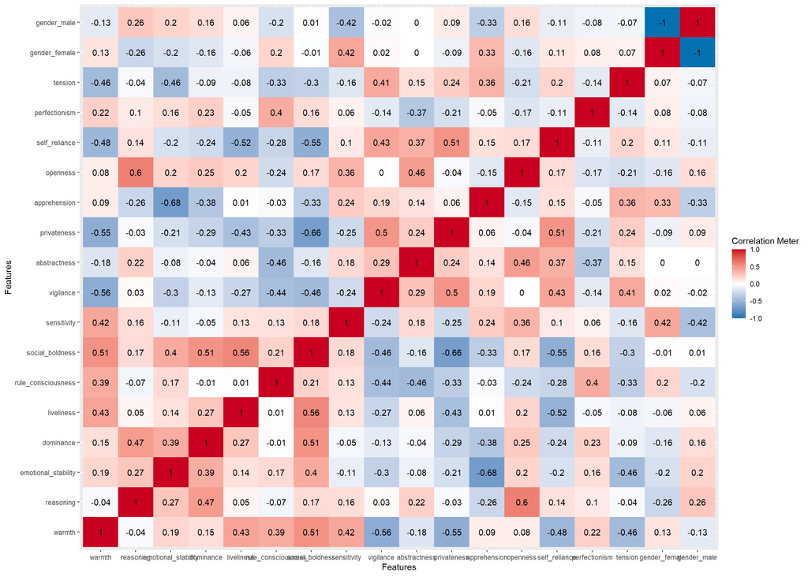

## Separamos en grupo de entrenamiento y grupo test

```r
set.seed(975)
split <- rsample::initial_split(
  Train_data,
  strata = gender,
  prop = 0.8
)

split
```

```
## <Training/Testing/Total>
## <329/83/412>
```

## Procesamiento automático

##### Creamos un objeto para el preprocesamiento automático

```r
preprocesador <- recipes::recipe(gender ~ ., data = rsample::training(split)) %>%
  # Imputar valores ausentes
  recipes::step_naomit(all_outcomes()) %>%                               # Elimina missings en variable resultado
  recipes::step_impute_median(all_numeric_predictors()) %>%              # Al ser variables ordinales que van de 1 a 5 elegimos imputar con la mediana
  # Reducción de datos
  recipes::step_corr(all_numeric_predictors(), threshold = 0.9) %>%      # Elimina variables altamente correlacionadas
  recipes::step_nzv(all_predictors()) %>%                                # Elimina predictores con varianza muy baja o nula
  # Transformación y normalización de datos
  recipes::step_center(all_numeric_predictors()) %>%                    # Calcula X - Media
  recipes::step_scale(all_numeric_predictors())                         # Divide por SD. Juntas calculan z scores

preprocesador
```

# Probamos diferentes modelos para la base de datos completa

> Se optó por comparar 3 modelos: - El Support Vector Machines (SVM) por combinar aspectos de KNN y regresión, ser bueno en problemas no lineales y de clasificación binaria y no hacer supocisiones sobre la distribución de los predictores. A su vez es bueno con muchas dimensiones. Por más de que no permite ver intuitivamente cuáles son los principáles predictores parece ser un buen método para esta tarea. - El LightGBM por ser un algoritmo de boosting basado en árboles de decisiones. Nos permite controlar el sobreajuste. Permite una identificación implícita de las variables más relevantes para la predicción. - Elastic Net por ser una combinación entre Lasso y Ridge. Permite una identificación implícita de las variables más relevantes para la predicción.

```r
# mejoramos la capacidad de cómputo
doParallel::registerDoParallel(cores = detectCores())
```

```r
# Separamos la muestra de entrenamiento en 10 partes

set.seed(975)
cv_folds <- rsample::vfold_cv(
  training(split),
  strata = gender,
  v = 10,
  repeats = 10
)
```

## Support Vector Machine Linear - con parámetros que vienen por defecto

```r
svm_Train_data_model_base <- parsnip::svm_linear(
  mode = "classification",
  cost = NULL,      #default 1.0
  margin = NULL) %>%   #default 0.1
 set_engine("kernlab")
```

```r
# Creamos un workflow con el preprocesador y el modelo
svm_Train_data_wflow_base <- workflows::workflow() %>%
  workflows::add_recipe(preprocesador) %>%
  workflows::add_model(svm_Train_data_model_base)
```

```r
# Realizar la validación cruzada y guardar los resultados en un tibble

set.seed(975)
svm_Train_data_result_base <- svm_Train_data_wflow_base %>%
  tune::fit_resamples(
    cv_folds,
    metrics = yardstick::metric_set(accuracy)) %>%
  tune::collect_metrics(summarize = FALSE) %>%
  dplyr::select(id, .metric, .estimate) %>%
  dplyr::mutate(model = "SVM_Train_data_model_base")
```

```r
# Mostrar las métricas de la validación cruzada

svm_Train_data_result_base %>%
  dplyr::group_by(.metric) %>%
  dplyr::summarise(mean = mean(.estimate), n_folds = n())
```

```
## # A tibble: 1 × 3
##   .metric   mean n_folds
##   <chr>    <dbl>   <int>
## 1 accuracy 0.744     100
```

```r
# Realizar el último ajuste del modelo con todos los datos de entrenamiento

svm_base_modelo_final <- tune::last_fit(
  svm_Train_data_wflow_base,
  split = split,
  metrics = yardstick::metric_set(accuracy))
```

```r
# Métricas sobre los datos del test

svm_base_Train_data_result_test <- svm_base_modelo_final %>%
  tune::collect_metrics()%>%
  dplyr::select(.metric, .estimate) %>%
  dplyr::mutate(model = "SVM_Train_data_base_train")

svm_base_Train_data_result_test
```

```
## # A tibble: 1 × 3
##   .metric  .estimate model
##   <chr>        <dbl> <chr>
## 1 accuracy     0.783 SVM_Train_data_base_train
```

```r
# Predicciones sobre los datos del test

svm_base_modelo_final %>%
  tune::collect_predictions()
```

```
## # A tibble: 83 × 5
##    .pred_class id                .row gender .config
##    <fct>       <chr>            <int> <fct>  <chr>
##  1 female      train/test split     1 female Preprocessor1_Model1
##  2 female      train/test split     2 female Preprocessor1_Model1
##  3 female      train/test split     3 female Preprocessor1_Model1
##  4 female      train/test split    10 female Preprocessor1_Model1
##  5 male        train/test split    12 female Preprocessor1_Model1
##  6 female      train/test split    24 female Preprocessor1_Model1
##  7 female      train/test split    41 female Preprocessor1_Model1
##  8 female      train/test split    45 female Preprocessor1_Model1
##  9 female      train/test split    46 female Preprocessor1_Model1
## 10 male        train/test split    52 female Preprocessor1_Model1
## # ℹ 73 more rows
```

## Support Vector Machine Linear - con ajuste de hiperparámetros (Técnica Bayesiana)

```r
# Definimos el modelo base SVM con los hiperparámetros a ajustar (cost y margin)
svm_tuned_model <- parsnip::svm_linear(
  mode = "classification",
  cost = tune(),   # Hiperparámetro a ajustar
  margin = tune()  # Hiperparámetro a ajustar
) %>%
  set_engine("kernlab")
```

```r
# Workflow
svm_tuned_wflow <- workflows::workflow() %>%
  workflows::add_recipe(preprocesador) %>%
  workflows::add_model(svm_tuned_model)
```

```r
# Usamos tune_bayes() para optimizar los parámetros

set.seed(975)

svm_tuned_results <- tune::tune_bayes(
  svm_tuned_wflow,
  resamples = cv_folds,
  initial = 15,       # Configuraciones iniciales
  iter = 100,         # Iteraciones de búsqueda
  metrics = yardstick::metric_set(accuracy)
)
```

```r
# Mostramos los mejores hiperparámetros:

svm_tuned_results %>%
  tune::show_best(metric = "accuracy", n = 10)
```

```
## # A tibble: 10 × 9
##      cost   margin .metric  .estimator  mean     n std_err .config .iter
##     <dbl>    <dbl> <chr>    <chr>      <dbl> <int>   <dbl> <chr>   <int>
##  1 0.0818 0.000895 accuracy binary     0.751   100 0.00706 Iter14     14
##  2 0.0817 0.0251   accuracy binary     0.751   100 0.00701 Iter24     24
##  3 0.0809 0.0516   accuracy binary     0.751   100 0.00706 Iter5       5
##  4 0.0816 0.115    accuracy binary     0.751   100 0.00706 Iter20     20
##  5 0.0829 0.198    accuracy binary     0.751   100 0.00711 Iter2       2
##  6 0.0826 0.00497  accuracy binary     0.751   100 0.00711 Iter7       7
##  7 0.0791 0.122    accuracy binary     0.751   100 0.00702 Iter10     10
##  8 0.0809 0.138    accuracy binary     0.751   100 0.00704 Iter23     23
##  9 0.103  0.127    accuracy binary     0.750   100 0.00705 Iter18     18
## 10 0.106  0.0246   accuracy binary     0.750   100 0.00707 Iter21     21
```

```r
# Seleccionar los mejores hiperparámetros
svm_tuned_best_params <- svm_tuned_results %>%
  tune::select_best(metric = "accuracy")

# Guardar resultados de la validación cruzada
svm_tuned_results_cv <- svm_tuned_results %>%
  tune::collect_metrics(summarize = FALSE) %>%
  dplyr::filter(.config == svm_tuned_best_params$.config) %>%
  dplyr::select(id, .metric, .estimate) %>%
  dplyr::mutate(model = "SVM_tuned")

# Resumen de métricas
svm_tuned_results_cv %>%
  dplyr::group_by(.metric) %>%
  dplyr::summarise(mean = mean(.estimate), n_folds = n())
```

```
## # A tibble: 1 × 3
##   .metric   mean n_folds
##   <chr>    <dbl>   <int>
## 1 accuracy 0.751     100
```

```r
# Asignamos los mejores hiperparámetros al workflow y ajustamos el modelo final:

# Finalizar el workflow con los mejores hiperparámetros
svm_tuned_wflow_final <- svm_tuned_wflow %>%
  tune::finalize_workflow(svm_tuned_best_params)

# Ajustar el modelo final en los datos de entrenamiento
svm_tuned_final <- tune::last_fit(
  svm_tuned_wflow_final,
  split = split,
  metrics = yardstick::metric_set(accuracy)
)

# Métricas en los datos de prueba
svm_tuned_results_test <- svm_tuned_final %>%
  tune::collect_metrics() %>%
  dplyr::select(.metric, .estimate) %>%
  dplyr::mutate(model = "SVM_tuned_test")

svm_tuned_results_test
```

```
## # A tibble: 1 × 3
##   .metric  .estimate model
##   <chr>        <dbl> <chr>
## 1 accuracy     0.771 SVM_tuned_test
```

## LightGBM - con los parámetros que vienen por defecto

```r
# Creamos el modelo
lightgbm_base_model <- parsnip::boost_tree(
  mode = "classification",
  tree_depth = NULL,           # Default: -1
  trees = NULL,                # Default: 100
  learn_rate = NULL,           # Default: 0.1
  min_n = NULL) %>%            # Default: 20
  set_engine("xgboost") %>%
  translate()

# Creamos un workflow con el preprocesador y el modelo
lightgbm_base_wflow <- workflows::workflow() %>%
  workflows::add_recipe(preprocesador) %>%
  workflows::add_model(lightgbm_base_model)
```

```r
# Realizar la validación cruzada y guardar los resultados en un tibble
set.seed(975)
lightgbm_base_result_cv <- lightgbm_base_wflow %>%
  tune::fit_resamples(
    cv_folds,
    metrics = yardstick::metric_set(accuracy)) %>%
  tune::collect_metrics(summarize = FALSE) %>%
  dplyr::select(id, .metric, .estimate) %>%
  dplyr::mutate(model = "lightgbm_base_model")

# Mostrar las métricas de la validación cruzada
lightgbm_base_result_cv %>%
  dplyr::group_by(.metric) %>%
  dplyr::summarise(mean = mean(.estimate), n_folds = n())
```

```
## # A tibble: 1 × 3
##   .metric   mean n_folds
##   <chr>    <dbl>   <int>
## 1 accuracy 0.744     100
```

```r
# Realizar el último ajuste del modelo con todos los datos de entrenamiento
lightgbm_base_final <- tune::last_fit(lightgbm_base_wflow, split = split, metrics = yardstick::metric_set(accuracy))

# Métricas sobre los datos del test
lightgbm_base_result_test <- lightgbm_base_final %>%
  tune::collect_metrics() %>%
  dplyr::select(.metric, .estimate) %>%
  dplyr::mutate(model = "LightGBM_base_test")

lightgbm_base_result_test
```

```
## # A tibble: 1 × 3
##   .metric  .estimate model
##   <chr>        <dbl> <chr>
## 1 accuracy     0.723 LightGBM_base_test
```

## LightGBM - “tuning” de los hiperparámetros (Bayes)

```r
lightgbm_tuned_model <- parsnip::boost_tree(
  mode = "classification",
  tree_depth = tune(),           # Default: -1
  trees = tune(),                # Default: 100
  learn_rate = tune(),           # Default: 0.1
  min_n = tune()) %>%            # Default: 20
  set_engine("xgboost", counts = FALSE) %>%
  translate()

# Creamos un workflow con el preprocesador y el modelo
lightgbm_tuned_wflow <- workflows::workflow() %>%
  workflows::add_recipe(preprocesador) %>%
  workflows::add_model(lightgbm_tuned_model)
```

```r
# Usar optimización bayesiana para buscar los mejores hiperparámetros
set.seed(975)
lightgbm_tuned_search_results <- tune::tune_bayes(
  lightgbm_tuned_wflow,
  cv_folds,
  initial = 15,
  iter = 100,
  metrics = yardstick::metric_set(accuracy))

# Mostrar los mejores hiperparámetros
lightgbm_tuned_search_results %>%
  tune::show_best(n = 5)
```

```
## # A tibble: 5 × 11
##   trees min_n tree_depth learn_rate .metric  .estimator  mean     n std_err
##   <int> <int>      <int>      <dbl> <chr>    <chr>      <dbl> <int>   <dbl>
## 1   528    12         15    0.0153  accuracy binary     0.752   100 0.00673
## 2   342     7          5    0.00637 accuracy binary     0.747   100 0.00763
## 3  1789     6         13    0.00390 accuracy binary     0.746   100 0.00728
## 4  1593     4         13    0.0492  accuracy binary     0.744   100 0.00727
## 5  1991     2         12    0.00423 accuracy binary     0.744   100 0.00733
## # ℹ 2 more variables: .config <chr>, .iter <int>
```

```r
# Seleccionar los mejores hiperparámetros
lightgbm_tuned_best_params <- lightgbm_tuned_search_results %>%
  tune::select_best(metric = "accuracy")

# Guardar, del mejor modelo, los resultados de la validación cruzada en un tibble
lightgbm_tuned_results_cv <- lightgbm_tuned_search_results  %>%
  tune::collect_metrics(summarize = FALSE) %>%
  dplyr::filter(.config == lightgbm_tuned_best_params$.config) %>%
  dplyr::select(id, .metric, .estimate) %>%
  dplyr::mutate(model = "LightGBM_tuned")

# Mostrar las métricas de la validación cruzada
lightgbm_tuned_results_cv %>%
  dplyr::group_by(.metric) %>%
  dplyr::summarise(mean = mean(.estimate), n_folds = n())
```

```
## # A tibble: 1 × 3
##   .metric   mean n_folds
##   <chr>    <dbl>   <int>
## 1 accuracy 0.752     100
```

```r
# Finalizar el workflow con los mejores hiperparámetros: asignamos los mejores hiperárámetros encontrados
lightgbm_tuned_wflow_final <- lightgbm_tuned_wflow %>%
  tune::finalize_workflow(lightgbm_tuned_best_params)

lightgbm_tuned_wflow_final
```

```
## ══ Workflow ════════════════════════════════════════════════════════════════════
## Preprocessor: Recipe
## Model: boost_tree()
##
## ── Preprocessor ────────────────────────────────────────────────────────────────
## 6 Recipe Steps
##
## • step_naomit()
## • step_impute_median()
## • step_corr()
## • step_nzv()
## • step_center()
## • step_scale()
##
## ── Model ───────────────────────────────────────────────────────────────────────
## Boosted Tree Model Specification (classification)
##
## Main Arguments:
##   trees = 528
##   min_n = 12
##   tree_depth = 15
##   learn_rate = 0.015340920126261
##
## Engine-Specific Arguments:
##   counts = FALSE
##
## Computational engine: xgboost
```

```r
# Realizar el último ajuste del modelo con todos los datos de entrenamiento
lightgbm_tuned_final <- tune::last_fit(lightgbm_tuned_wflow_final, split = split, metrics =  yardstick::metric_set(accuracy))

# Métricas sobre los datos del test
lightgbm_tuned_results_test <- lightgbm_tuned_final %>%
  tune::collect_metrics() %>%
  dplyr::select(.metric, .estimate) %>%
  dplyr::mutate(model = "LightGBM_tuned_test")

lightgbm_tuned_results_test
```

```
## # A tibble: 1 × 3
##   .metric  .estimate model
##   <chr>        <dbl> <chr>
## 1 accuracy     0.735 LightGBM_tuned_test
```

## Elastic Net - con los parámetros que vienen por defecto

```r
EN_base_model <- parsnip::logistic_reg(
  mode = "classification",
  penalty = 0.1,               # NO Default
  mixture = 0.5) %>%             # 0: Ridge | 1: Lasso
  set_engine("glmnet")

# Creamos un workflow con el preprocesador y el modelo
EN_base_wflow <- workflows::workflow() %>%
  workflows::add_recipe(preprocesador) %>%
  workflows::add_model(EN_base_model)
```

```r
# Realizar la validación cruzada y guardar los resultados en un tibble
set.seed(975)
EN_base_result_cv <- EN_base_wflow %>%
  tune::fit_resamples(
    cv_folds,
    metrics = yardstick::metric_set(accuracy)) %>%
  tune::collect_metrics(summarize = FALSE) %>%
  dplyr::select(id, .metric, .estimate) %>%
  dplyr::mutate(model = "EN_base")

# Mostrar las métricas de la validación cruzada
EN_base_result_cv %>%
  dplyr::group_by(.metric) %>%
  dplyr::summarise(mean = mean(.estimate), n_folds = n())
```

```
## # A tibble: 1 × 3
##   .metric   mean n_folds
##   <chr>    <dbl>   <int>
## 1 accuracy 0.727     100
```

```r
# Realizar el último ajuste del modelo con todos los datos de entrenamiento
EN_base_final <- tune::last_fit(
  EN_base_wflow,
  split = split,
  metrics = yardstick::metric_set(accuracy))

# Métricas sobre los datos del test
EN_base_result_test <- EN_base_final %>%
  tune::collect_metrics() %>%
  dplyr::select(.metric, .estimate) %>%
  dplyr::mutate(model = "EN_base_test")

EN_base_result_test
```

```
## # A tibble: 1 × 3
##   .metric  .estimate model
##   <chr>        <dbl> <chr>
## 1 accuracy     0.747 EN_base_test
```

## ElasticNet - “tuning” de los hiperparámetros (Bayes)

```r
elastic_base_model <- parsnip::logistic_reg(
  mode = "classification",
  penalty = tune(),                 # NO Default
  mixture = tune()) %>%             # 0: Ridge | 1: Lasso
  set_engine("glmnet")

# Creamos un workflow con el preprocesador y el modelo
elastic_tuned_wflow <- workflows::workflow() %>%
  workflows::add_recipe(preprocesador) %>%
  workflows::add_model(elastic_base_model)
```

```r
# Usar optimización bayesiana para buscar los mejores hiperparámetros
set.seed(975)
elastic_tuned_search_results <- tune::tune_bayes(
  elastic_tuned_wflow,
  cv_folds,
  initial = 15,
  iter = 100,
  metrics = yardstick::metric_set(accuracy))

# Mostrar los mejores hiperparámetros
elastic_tuned_search_results %>%
  tune::show_best(n = 10)
```

```
## # A tibble: 10 × 9
##     penalty mixture .metric  .estimator  mean     n std_err .config        .iter
##       <dbl>   <dbl> <chr>    <chr>      <dbl> <int>   <dbl> <chr>          <int>
##  1 1.70e- 2   0.478 accuracy binary     0.733   100 0.00740 Preprocessor1…     0
##  2 2.25e- 6   0.360 accuracy binary     0.732   100 0.00768 Preprocessor1…     0
##  3 1.10e- 5   0.557 accuracy binary     0.732   100 0.00768 Preprocessor1…     0
##  4 4.39e- 7   0.624 accuracy binary     0.732   100 0.00768 Preprocessor1…     0
##  5 4.46e-10   0.537 accuracy binary     0.732   100 0.00768 Iter7              7
##  6 6.51e- 5   0.795 accuracy binary     0.732   100 0.00766 Preprocessor1…     0
##  7 1.85e-10   0.817 accuracy binary     0.732   100 0.00766 Preprocessor1…     0
##  8 4.19e- 9   0.764 accuracy binary     0.732   100 0.00766 Iter9              9
##  9 1.77e- 2   0.218 accuracy binary     0.732   100 0.00700 Iter10            10
## 10 1.50e- 4   0.991 accuracy binary     0.732   100 0.00763 Preprocessor1…     0
```

```r
# Seleccionar los mejores hiperparámetros
elastic_tuned_best_params <- elastic_tuned_search_results %>%
  tune::select_best(metric = "accuracy")

# Guardar, del mejor modelo, los resultados de la validación cruzada en un tibble
elastic_tuned_results_cv <- elastic_tuned_search_results  %>%
  tune::collect_metrics(summarize = FALSE) %>%
  dplyr::filter(.config == elastic_tuned_best_params$.config) %>%
  dplyr::select(id, .metric, .estimate) %>%
  dplyr::mutate(model = "Elastic_tuned")

# Mostrar las métricas de la validación cruzada
elastic_tuned_results_cv %>%
  dplyr::group_by(.metric) %>%
  dplyr::summarise(mean = mean(.estimate), n_folds = n())
```

```
## # A tibble: 1 × 3
##   .metric   mean n_folds
##   <chr>    <dbl>   <int>
## 1 accuracy 0.733     100
```

```r
# Finalizar el workflow con los mejores hiperparámetros: asignamos los mejores hiperárámetros encontrados
elastic_tuned_wflow_final <- elastic_tuned_wflow %>%
  tune::finalize_workflow(elastic_tuned_best_params)

elastic_tuned_wflow_final
```

```
## ══ Workflow ════════════════════════════════════════════════════════════════════
## Preprocessor: Recipe
## Model: logistic_reg()
##
## ── Preprocessor ────────────────────────────────────────────────────────────────
## 6 Recipe Steps
##
## • step_naomit()
## • step_impute_median()
## • step_corr()
## • step_nzv()
## • step_center()
## • step_scale()
##
## ── Model ───────────────────────────────────────────────────────────────────────
## Logistic Regression Model Specification (classification)
##
## Main Arguments:
##   penalty = 0.0169853722061577
##   mixture = 0.4782054884367
##
## Computational engine: glmnet
```

```r
# Realizar el último ajuste del modelo con todos los datos de entrenamiento
elastic_tuned_final <- tune::last_fit(elastic_tuned_wflow_final, split = split, metrics = yardstick::metric_set(accuracy))

# Métricas sobre los datos del test
elastic_tuned_results_test <- elastic_tuned_final %>%
  tune::collect_metrics() %>%
  dplyr::select(.metric, .estimate) %>%
  dplyr::mutate(model = "Elastic_tuned_test")

elastic_tuned_results_test
```

```
## # A tibble: 1 × 3
##   .metric  .estimate model
##   <chr>        <dbl> <chr>
## 1 accuracy     0.771 Elastic_tuned_test
```

# Compamos modelos

```r
metrica_a_graficar = "accuracy"

# Tabla de los resultados de la validación cruzada
dplyr::bind_rows(
  svm_Train_data_result_base,
  svm_tuned_results_cv,
  lightgbm_base_result_cv,
  lightgbm_tuned_results_cv,
  EN_base_result_cv,
  elastic_tuned_results_cv,
) %>%
  dplyr::group_by(model, .metric) %>%
  dplyr::filter(.metric == metrica_a_graficar) %>%
  dplyr::summarise(mean = mean(.estimate), sd = sd(.estimate), n_folds = n())
```

```
## # A tibble: 6 × 5
## # Groups:   model [6]
##   model                     .metric   mean     sd n_folds
##   <chr>                     <chr>    <dbl>  <dbl>   <int>
## 1 EN_base                   accuracy 0.727 0.0632     100
## 2 Elastic_tuned             accuracy 0.733 0.0740     100
## 3 LightGBM_tuned            accuracy 0.752 0.0673     100
## 4 SVM_Train_data_model_base accuracy 0.744 0.0713     100
## 5 SVM_tuned                 accuracy 0.751 0.0706     100
## 6 lightgbm_base_model       accuracy 0.744 0.0657     100
```

```r
# Tabla de los resultados del test
dplyr::bind_rows(
  svm_base_Train_data_result_test,
  svm_tuned_results_test,
  lightgbm_base_result_test,
  lightgbm_tuned_results_test,
  EN_base_result_test,
  elastic_tuned_results_test,
) %>%
  dplyr::group_by(model, .metric) %>%
  dplyr::filter(.metric == metrica_a_graficar) %>%
  dplyr::summarise(mean = mean(.estimate), n_folds = n())
```

```
## # A tibble: 6 × 4
## # Groups:   model [6]
##   model                     .metric   mean n_folds
##   <chr>                     <chr>    <dbl>   <int>
## 1 EN_base_test              accuracy 0.747       1
## 2 Elastic_tuned_test        accuracy 0.771       1
## 3 LightGBM_base_test        accuracy 0.723       1
## 4 LightGBM_tuned_test       accuracy 0.735       1
## 5 SVM_Train_data_base_train accuracy 0.783       1
## 6 SVM_tuned_test            accuracy 0.771       1
```

> Al evaluar la performance de los modelos en el grupo de test, se observa que el modelo con mejor accuracy es el SVM base, sin ajustar hiperparámetros.

# Probamos diferentes transformaciones

## Buscamos variables con alto nivel de curtosis

```r
psych::describe(Train_data)
```

```
##                     vars   n mean   sd median trimmed  mad  min  max range
## gender*                1 412 1.41 0.49   1.00    1.38 0.00 1.00 2.00  1.00
## warmth                 2 392 3.68 0.62   3.78    3.72 0.49 1.00 5.00  4.00
## reasoning              3 396 3.72 0.51   3.75    3.73 0.49 2.33 4.83  2.50
## emotional_stability    4 388 3.31 0.45   3.33    3.33 0.49 1.89 4.33  2.44
## dominance              5 384 3.47 0.64   3.56    3.50 0.66 1.56 5.00  3.44
## liveliness             6 389 3.35 0.63   3.33    3.36 0.66 1.44 5.00  3.56
## rule_consciousness     7 392 3.16 0.75   3.22    3.18 0.82 1.00 4.89  3.89
## social_boldness        8 392 3.11 0.85   3.22    3.14 0.99 1.00 5.00  4.00
## sensitivity            9 390 3.44 0.60   3.44    3.46 0.66 1.67 5.00  3.33
## vigilance             10 392 2.93 0.70   2.89    2.90 0.66 1.33 5.00  3.67
## abstractness          11 395 3.48 0.65   3.56    3.51 0.66 1.44 4.78  3.33
## privateness           12 392 2.96 0.79   2.89    2.94 0.82 1.22 4.89  3.67
## apprehension          13 396 3.17 0.77   3.22    3.18 0.82 1.11 5.00  3.89
## openness              14 390 3.78 0.59   3.78    3.79 0.66 2.11 5.00  2.89
## self_reliance         15 394 3.46 0.65   3.44    3.45 0.66 1.44 5.00  3.56
## perfectionism         16 390 3.08 0.68   3.00    3.08 0.66 1.56 5.00  3.44
## tension               17 395 2.81 0.65   2.78    2.81 0.66 1.00 4.44  3.44
##                      skew kurtosis   se
## gender*              0.37    -1.86 0.02
## warmth              -0.82     1.40 0.03
## reasoning           -0.09    -0.36 0.03
## emotional_stability -0.42    -0.25 0.02
## dominance           -0.32    -0.28 0.03
## liveliness          -0.14    -0.06 0.03
## rule_consciousness  -0.25     0.00 0.04
## social_boldness     -0.22    -0.61 0.04
## sensitivity         -0.21    -0.20 0.03
## vigilance            0.42    -0.06 0.04
## abstractness        -0.43     0.07 0.03
## privateness          0.18    -0.46 0.04
## apprehension        -0.14    -0.37 0.04
## openness            -0.20    -0.35 0.03
## self_reliance       -0.03    -0.03 0.03
## perfectionism        0.14    -0.37 0.03
## tension             -0.02    -0.30 0.03
```

```r
# Transformación logística
Base_Transf <- Train_data %>%
  mutate(warmth = log(warmth + 1))

skimr::skim(Base_Transf)
```

Data summary

| Name | Base_Transf |
| --- | --- |
| Number of rows | 412 |
| Number of columns | 17 |
| _______________________ |  |
| Column type frequency: |  |
| factor | 1 |
| numeric | 16 |
| ________________________ |  |
| Group variables | None |

**Variable type: factor**

| skim_variable | n_missing | complete_rate | ordered | n_unique | top_counts |
| --- | --- | --- | --- | --- | --- |
| gender | 0 | 1 | FALSE | 2 | fem: 244, mal: 168 |

**Variable type: numeric**

| skim_variable | n_missing | complete_rate | mean | sd | p0 | p25 | p50 | p75 | p100 | hist |
| --- | --- | --- | --- | --- | --- | --- | --- | --- | --- | --- |
| warmth | 20 | 0.95 | 1.53 | 0.14 | 0.69 | 1.47 | 1.56 | 1.63 | 1.79 | ▁▁▂▇▇ |
| reasoning | 16 | 0.96 | 3.72 | 0.51 | 2.33 | 3.33 | 3.75 | 4.08 | 4.83 | ▁▅▇▇▂ |
| emotional_stability | 24 | 0.94 | 3.31 | 0.45 | 1.89 | 3.00 | 3.33 | 3.67 | 4.33 | ▁▃▇▇▂ |
| dominance | 28 | 0.93 | 3.47 | 0.64 | 1.56 | 3.00 | 3.56 | 3.89 | 5.00 | ▁▃▇▇▂ |
| liveliness | 23 | 0.94 | 3.35 | 0.63 | 1.44 | 2.89 | 3.33 | 3.78 | 5.00 | ▁▃▇▅▁ |
| rule_consciousness | 20 | 0.95 | 3.16 | 0.75 | 1.00 | 2.67 | 3.22 | 3.67 | 4.89 | ▁▃▇▆▂ |
| social_boldness | 20 | 0.95 | 3.11 | 0.85 | 1.00 | 2.44 | 3.22 | 3.69 | 5.00 | ▂▅▇▇▃ |
| sensitivity | 22 | 0.95 | 3.44 | 0.60 | 1.67 | 3.00 | 3.44 | 3.89 | 5.00 | ▁▅▇▇▁ |
| vigilance | 20 | 0.95 | 2.93 | 0.70 | 1.33 | 2.42 | 2.89 | 3.33 | 5.00 | ▂▇▇▃▁ |
| abstractness | 17 | 0.96 | 3.48 | 0.65 | 1.44 | 3.11 | 3.56 | 3.89 | 4.78 | ▁▂▆▇▃ |
| privateness | 20 | 0.95 | 2.96 | 0.79 | 1.22 | 2.44 | 2.89 | 3.56 | 4.89 | ▃▇▇▆▂ |
| apprehension | 16 | 0.96 | 3.17 | 0.77 | 1.11 | 2.64 | 3.22 | 3.67 | 5.00 | ▁▅▇▇▂ |
| openness | 22 | 0.95 | 3.78 | 0.59 | 2.11 | 3.44 | 3.78 | 4.22 | 5.00 | ▁▃▇▇▃ |
| self_reliance | 18 | 0.96 | 3.46 | 0.65 | 1.44 | 3.00 | 3.44 | 3.89 | 5.00 | ▁▂▇▆▂ |
| perfectionism | 22 | 0.95 | 3.08 | 0.68 | 1.56 | 2.58 | 3.00 | 3.56 | 5.00 | ▃▇▇▅▁ |
| tension | 17 | 0.96 | 2.81 | 0.65 | 1.00 | 2.44 | 2.78 | 3.33 | 4.44 | ▁▃▇▅▂ |

## preprocesador_t con transformaciones

```r
set.seed(975)
split_t <- rsample::initial_split(
  Base_Transf,
  strata = gender,
  prop = 0.8
)

split_t
```

```
## <Training/Testing/Total>
## <329/83/412>
```

```r
set.seed(975)
cv_folds_t <- rsample::vfold_cv(
  training(split_t),
  strata = gender,
  v = 10,
  repeats = 10
)
```

```r
preprocesador_t <- recipes::recipe(gender ~ ., data = rsample::training(split_t)) %>%
  # Imputar valores ausentes
  recipes::step_naomit(all_outcomes()) %>%                               # Elimina missings en variable resultado
  recipes::step_impute_median(all_numeric_predictors()) %>%              # Al ser variables ordinales que van de 1 a 5 elegimos imputar con la mediana
  # Reducción de datos
  recipes::step_corr(all_numeric_predictors(), threshold = 0.9) %>%      # Elimina variables altamente correlacionadas
  recipes::step_nzv(all_predictors()) %>%                                # Elimina predictores con varianza muy baja o nula
  # Transformación y normalización de datos
  recipes::step_center(all_numeric_predictors()) %>%                    # Calcula X - Media
  recipes::step_scale(all_numeric_predictors())                         # Divide por SD. Juntas calculan z scores

preprocesador_t
```

## Support Vector Machine Linear - con parámetros que vienen por defecto

```r
svm_Train_data_model_base_t <- parsnip::svm_linear(
  mode = "classification",
  cost = NULL,      #default 1.0
  margin = NULL) %>%   #default 0.1
 set_engine("kernlab")
```

```r
# Creamos un workflow con el preprocesador_t y el modelo
svm_Train_data_wflow_base_t <- workflows::workflow() %>%
  workflows::add_recipe(preprocesador_t) %>%
  workflows::add_model(svm_Train_data_model_base_t)
```

```r
# Realizar la validación cruzada y guardar los resultados en un tibble

set.seed(975)
svm_Train_data_result_base_t <- svm_Train_data_wflow_base_t %>%
  tune::fit_resamples(
    cv_folds_t,
    metrics = yardstick::metric_set(accuracy)) %>%
  tune::collect_metrics(summarize = FALSE) %>%
  dplyr::select(id, .metric, .estimate) %>%
  dplyr::mutate(model = "svm_Train_data_model_base_cv_t")
```

```r
# Mostrar las métricas de la validación cruzada

svm_Train_data_result_base_t %>%
  dplyr::group_by(.metric) %>%
  dplyr::summarise(mean = mean(.estimate), n_folds = n())
```

```
## # A tibble: 1 × 3
##   .metric   mean n_folds
##   <chr>    <dbl>   <int>
## 1 accuracy 0.745     100
```

```r
# Realizar el último ajuste del modelo con todos los datos de entrenamiento

svm_base_modelo_final_t <- tune::last_fit(
  svm_Train_data_wflow_base_t,
  split = split_t,
  metrics = yardstick::metric_set(accuracy))
```

```r
# Métricas sobre los datos del test

svm_base_Train_data_result_test_t <- svm_base_modelo_final_t %>%
  tune::collect_metrics()%>%
  dplyr::select(.metric, .estimate) %>%
  dplyr::mutate(model = "SVM_Train_data_t_test")

svm_base_Train_data_result_test_t
```

```
## # A tibble: 1 × 3
##   .metric  .estimate model
##   <chr>        <dbl> <chr>
## 1 accuracy     0.795 SVM_Train_data_t_test
```

## Support Vector Machine Linear - con ajuste de hiperparámetros (Bayes)

```r
# Definimos el modelo base SVM con los hiperparámetros a ajustar (cost y margin)
svm_tuned_model_t <- parsnip::svm_linear(
  mode = "classification",
  cost = tune(),   # Hiperparámetro a ajustar
  margin = tune()  # Hiperparámetro a ajustar
) %>%
  set_engine("kernlab")
```

```r
# Workflow
svm_tuned_wflow_t <- workflows::workflow() %>%
  workflows::add_recipe(preprocesador_t) %>%
  workflows::add_model(svm_tuned_model_t)
```

```r
# Usamos tune_bayes() para optimizar los parámetros

set.seed(975)

svm_tuned_results_t <- tune::tune_bayes(
  svm_tuned_wflow_t,
  resamples = cv_folds_t,
  initial = 15,       # Configuraciones iniciales
  iter = 100,         # Iteraciones de búsqueda
  metrics = yardstick::metric_set(accuracy)
)
```

```r
# Mostramos los mejores hiperparámetros:

svm_tuned_results_t %>%
  tune::show_best(metric = "accuracy", n = 10)
```

```
## # A tibble: 10 × 9
##      cost  margin .metric  .estimator  mean     n std_err .config .iter
##     <dbl>   <dbl> <chr>    <chr>      <dbl> <int>   <dbl> <chr>   <int>
##  1 0.0670 0.00482 accuracy binary     0.751   100 0.00688 Iter6       6
##  2 0.0672 0.0550  accuracy binary     0.751   100 0.00688 Iter15     15
##  3 0.0669 0.00378 accuracy binary     0.751   100 0.00688 Iter16     16
##  4 0.0680 0.0237  accuracy binary     0.751   100 0.00692 Iter7       7
##  5 0.0661 0.197   accuracy binary     0.751   100 0.00689 Iter2       2
##  6 0.0659 0.0297  accuracy binary     0.751   100 0.00689 Iter9       9
##  7 0.0715 0.199   accuracy binary     0.750   100 0.00700 Iter5       5
##  8 0.0610 0.161   accuracy binary     0.750   100 0.00695 Iter4       4
##  9 0.153  0.0279  accuracy binary     0.749   100 0.00715 Iter13     13
## 10 0.0770 0.0191  accuracy binary     0.749   100 0.00702 Iter10     10
```

```r
# Seleccionar los mejores hiperparámetros
svm_tuned_best_params_t <- svm_tuned_results_t %>%
  tune::select_best(metric = "accuracy")

# Guardar resultados de la validación cruzada
svm_tuned_results_cv_t <- svm_tuned_results_t %>%
  tune::collect_metrics(summarize = FALSE) %>%
  dplyr::filter(.config == svm_tuned_best_params_t$.config) %>%
  dplyr::select(id, .metric, .estimate) %>%
  dplyr::mutate(model = "SVM_tuned_t_test")

# Resumen de métricas
svm_tuned_results_cv_t %>%
  dplyr::group_by(.metric) %>%
  dplyr::summarise(mean = mean(.estimate), n_folds = n())
```

```
## # A tibble: 1 × 3
##   .metric   mean n_folds
##   <chr>    <dbl>   <int>
## 1 accuracy 0.751     100
```

```r
# Asignamos los mejores hiperparámetros al workflow y ajustamos el modelo final:

# Finalizar el workflow con los mejores hiperparámetros
svm_tuned_wflow_final_t <- svm_tuned_wflow_t %>%
  tune::finalize_workflow(svm_tuned_best_params_t)

# Ajustar el modelo final en los datos de entrenamiento
svm_tuned_final_t <- tune::last_fit(
  svm_tuned_wflow_final_t,
  split = split_t,
  metrics = yardstick::metric_set(accuracy)
)

# Métricas en los datos de prueba
svm_tuned_results_test_t <- svm_tuned_final_t %>%
  tune::collect_metrics() %>%
  dplyr::select(.metric, .estimate) %>%
  dplyr::mutate(model = "SVM_tuned_t_test")

svm_tuned_results_test_t
```

```
## # A tibble: 1 × 3
##   .metric  .estimate model
##   <chr>        <dbl> <chr>
## 1 accuracy     0.771 SVM_tuned_t_test
```

## LightGBM - con los parámetros que vienen por defecto

```r
# Creamos el modelo
lightgbm_base_model_t <- parsnip::boost_tree(
  mode = "classification",
  tree_depth = NULL,           # Default: -1
  trees = NULL,                # Default: 100
  learn_rate = NULL,           # Default: 0.1
  min_n = NULL) %>%            # Default: 20
  set_engine("xgboost") %>%
  translate()

# Creamos un workflow con el preprocesador_t y el modelo
lightgbm_base_wflow_t <- workflows::workflow() %>%
  workflows::add_recipe(preprocesador_t) %>%
  workflows::add_model(lightgbm_base_model_t)
```

```r
# Realizar la validación cruzada y guardar los resultados en un tibble
set.seed(975)
lightgbm_base_result_cv_t <- lightgbm_base_wflow_t %>%
  tune::fit_resamples(
    cv_folds_t,
    metrics = yardstick::metric_set(accuracy)) %>%
  tune::collect_metrics(summarize = FALSE) %>%
  dplyr::select(id, .metric, .estimate) %>%
  dplyr::mutate(model = "lightgbm_base_model_t_cv")

# Mostrar las métricas de la validación cruzada
lightgbm_base_result_cv_t %>%
  dplyr::group_by(.metric) %>%
  dplyr::summarise(mean = mean(.estimate), n_folds = n())
```

```
## # A tibble: 1 × 3
##   .metric   mean n_folds
##   <chr>    <dbl>   <int>
## 1 accuracy 0.744     100
```

```r
# Realizar el último ajuste del modelo con todos los datos de entrenamiento
lightgbm_base_final_t <- tune::last_fit(lightgbm_base_wflow_t, split = split_t, metrics = yardstick::metric_set(accuracy))

# Métricas sobre los datos del test
lightgbm_base_result_test_t <- lightgbm_base_final_t %>%
  tune::collect_metrics() %>%
  dplyr::select(.metric, .estimate) %>%
  dplyr::mutate(model = "LightGBM_base_t_test")

lightgbm_base_result_test_t
```

```
## # A tibble: 1 × 3
##   .metric  .estimate model
##   <chr>        <dbl> <chr>
## 1 accuracy     0.723 LightGBM_base_t_test
```

## LightGBM - “tuning” de los hiperparámetros (Bayes)

```r
lightgbm_tuned_model_t <- parsnip::boost_tree(
  mode = "classification",
  tree_depth = tune(),           # Default: -1
  trees = tune(),                # Default: 100
  learn_rate = tune(),           # Default: 0.1
  min_n = tune()) %>%            # Default: 20
  set_engine("xgboost", counts = FALSE) %>%
  translate()

# Creamos un workflow con el preprocesador_t y el modelo
lightgbm_tuned_wflow_t <- workflows::workflow() %>%
  workflows::add_recipe(preprocesador_t) %>%
  workflows::add_model(lightgbm_tuned_model_t)
```

```r
# Usar optimización bayesiana para buscar los mejores hiperparámetros
set.seed(975)
lightgbm_tuned_search_results_t <- tune::tune_bayes(
  lightgbm_tuned_wflow_t,
  cv_folds_t,
  initial = 15,
  iter = 100,
  metrics = yardstick::metric_set(accuracy))

# Mostrar los mejores hiperparámetros
lightgbm_tuned_search_results_t %>%
  tune::show_best(n = 5)
```

```
## # A tibble: 5 × 11
##   trees min_n tree_depth learn_rate .metric  .estimator  mean     n std_err
##   <int> <int>      <int>      <dbl> <chr>    <chr>      <dbl> <int>   <dbl>
## 1   528    12         15    0.0153  accuracy binary     0.752   100 0.00673
## 2   342     7          5    0.00637 accuracy binary     0.747   100 0.00763
## 3  1789     6         13    0.00390 accuracy binary     0.746   100 0.00728
## 4  1593     4         13    0.0492  accuracy binary     0.744   100 0.00727
## 5  1991     2         12    0.00423 accuracy binary     0.744   100 0.00733
## # ℹ 2 more variables: .config <chr>, .iter <int>
```

```r
# Seleccionar los mejores hiperparámetros
lightgbm_tuned_best_params_t <- lightgbm_tuned_search_results_t %>%
  tune::select_best(metric = "accuracy")

# Guardar, del mejor modelo, los resultados de la validación cruzada en un tibble
lightgbm_tuned_results_cv_t <- lightgbm_tuned_search_results_t  %>%
  tune::collect_metrics(summarize = FALSE) %>%
  dplyr::filter(.config == lightgbm_tuned_best_params_t$.config) %>%
  dplyr::select(id, .metric, .estimate) %>%
  dplyr::mutate(model = "LightGBM_tuned_t_cv")

# Mostrar las métricas de la validación cruzada
lightgbm_tuned_results_cv_t %>%
  dplyr::group_by(.metric) %>%
  dplyr::summarise(mean = mean(.estimate), n_folds = n())
```

```
## # A tibble: 1 × 3
##   .metric   mean n_folds
##   <chr>    <dbl>   <int>
## 1 accuracy 0.752     100
```

```r
# Finalizar el workflow con los mejores hiperparámetros: asignamos los mejores hiperárámetros encontrados
lightgbm_tuned_wflow_final_t <- lightgbm_tuned_wflow_t %>%
  tune::finalize_workflow(lightgbm_tuned_best_params_t)

lightgbm_tuned_wflow_final_t
```

```
## ══ Workflow ════════════════════════════════════════════════════════════════════
## Preprocessor: Recipe
## Model: boost_tree()
##
## ── Preprocessor ────────────────────────────────────────────────────────────────
## 6 Recipe Steps
##
## • step_naomit()
## • step_impute_median()
## • step_corr()
## • step_nzv()
## • step_center()
## • step_scale()
##
## ── Model ───────────────────────────────────────────────────────────────────────
## Boosted Tree Model Specification (classification)
##
## Main Arguments:
##   trees = 528
##   min_n = 12
##   tree_depth = 15
##   learn_rate = 0.015340920126261
##
## Engine-Specific Arguments:
##   counts = FALSE
##
## Computational engine: xgboost
```

```r
# Realizar el último ajuste del modelo con todos los datos de entrenamiento
lightgbm_tuned_final_t <- tune::last_fit(lightgbm_tuned_wflow_final_t, split = split_t, metrics =  yardstick::metric_set(accuracy))

# Métricas sobre los datos del test
lightgbm_tuned_results_test_t <- lightgbm_tuned_final_t %>%
  tune::collect_metrics() %>%
  dplyr::select(.metric, .estimate) %>%
  dplyr::mutate(model = "LightGBM_tuned_t_test")

lightgbm_tuned_results_test_t
```

```
## # A tibble: 1 × 3
##   .metric  .estimate model
##   <chr>        <dbl> <chr>
## 1 accuracy     0.735 LightGBM_tuned_t_test
```

## Elastic Net - con los parámetros que vienen por defecto

```r
EN_base_model_t <- parsnip::logistic_reg(
  mode = "classification",
  penalty = 0.1,               # NO Default
  mixture = 0.5) %>%             # 0: Ridge | 1: Lasso
  set_engine("glmnet")

# Creamos un workflow con el preprocesador_t y el modelo
EN_base_wflow_t <- workflows::workflow() %>%
  workflows::add_recipe(preprocesador_t) %>%
  workflows::add_model(EN_base_model_t)
```

```r
# Realizar la validación cruzada y guardar los resultados en un tibble
set.seed(975)
EN_base_result_cv_t <- EN_base_wflow_t %>%
  tune::fit_resamples(
    cv_folds_t,
    metrics = yardstick::metric_set(accuracy)) %>%
  tune::collect_metrics(summarize = FALSE) %>%
  dplyr::select(id, .metric, .estimate) %>%
  dplyr::mutate(model = "EN_base")

# Mostrar las métricas de la validación cruzada
EN_base_result_cv_t %>%
  dplyr::group_by(.metric) %>%
  dplyr::summarise(mean = mean(.estimate), n_folds = n())
```

```
## # A tibble: 1 × 3
##   .metric   mean n_folds
##   <chr>    <dbl>   <int>
## 1 accuracy 0.727     100
```

```r
# Realizar el último ajuste del modelo con todos los datos de entrenamiento
EN_base_final_t <- tune::last_fit(
  EN_base_wflow_t,
  split = split_t,
  metrics = yardstick::metric_set(accuracy))

# Métricas sobre los datos del test
EN_base_result_test_t <- EN_base_final_t %>%
  tune::collect_metrics() %>%
  dplyr::select(.metric, .estimate) %>%
  dplyr::mutate(model = "EN_base_t")

EN_base_result_test_t
```

```
## # A tibble: 1 × 3
##   .metric  .estimate model
##   <chr>        <dbl> <chr>
## 1 accuracy     0.747 EN_base_t
```

## ElasticNet - “tuning” de los hiperparámetros (Bayes)

```r
elastic_base_model_t <- parsnip::logistic_reg(
  mode = "classification",
  penalty = tune(),                 # NO Default
  mixture = tune()) %>%             # 0: Ridge | 1: Lasso
  set_engine("glmnet")

# Creamos un workflow con el preprocesador_t y el modelo
elastic_tuned_wflow_t <- workflows::workflow() %>%
  workflows::add_recipe(preprocesador_t) %>%
  workflows::add_model(elastic_base_model_t)
```

```r
# Usar optimización bayesiana para buscar los mejores hiperparámetros
set.seed(975)
elastic_tuned_search_results_t <- tune::tune_bayes(
  elastic_tuned_wflow_t,
  cv_folds_t,
  initial = 15,
  iter = 100,
  metrics = yardstick::metric_set(accuracy))

# Mostrar los mejores hiperparámetros
elastic_tuned_search_results_t %>%
  tune::show_best(n = 10)
```

```
## # A tibble: 10 × 9
##     penalty mixture .metric  .estimator  mean     n std_err .config        .iter
##       <dbl>   <dbl> <chr>    <chr>      <dbl> <int>   <dbl> <chr>          <int>
##  1 1.70e- 2  0.478  accuracy binary     0.732   100 0.00743 Preprocessor1…     0
##  2 2.51e- 3  0.592  accuracy binary     0.732   100 0.00744 Iter8              8
##  3 2.25e- 6  0.360  accuracy binary     0.732   100 0.00774 Preprocessor1…     0
##  4 1.10e- 5  0.557  accuracy binary     0.732   100 0.00774 Preprocessor1…     0
##  5 1.26e- 2  0.0659 accuracy binary     0.732   100 0.00727 Iter1              1
##  6 2.21e- 9  0.263  accuracy binary     0.731   100 0.00776 Preprocessor1…     0
##  7 5.86e-10  0.579  accuracy binary     0.731   100 0.00773 Iter6              6
##  8 6.51e- 5  0.795  accuracy binary     0.731   100 0.00769 Preprocessor1…     0
##  9 1.85e-10  0.817  accuracy binary     0.731   100 0.00769 Preprocessor1…     0
## 10 2.02e- 9  0.185  accuracy binary     0.731   100 0.00780 Preprocessor1…     0
```

```r
# Seleccionar los mejores hiperparámetros
elastic_tuned_best_params_t <- elastic_tuned_search_results_t %>%
  tune::select_best(metric = "accuracy")

# Guardar, del mejor modelo, los resultados de la validación cruzada en un tibble
elastic_tuned_results_cv_t <- elastic_tuned_search_results_t  %>%
  tune::collect_metrics(summarize = FALSE) %>%
  dplyr::filter(.config == elastic_tuned_best_params_t$.config) %>%
  dplyr::select(id, .metric, .estimate) %>%
  dplyr::mutate(model = "elastic_base_model_t_cv")

# Mostrar las métricas de la validación cruzada
elastic_tuned_results_cv_t %>%
  dplyr::group_by(.metric) %>%
  dplyr::summarise(mean = mean(.estimate), n_folds = n())
```

```
## # A tibble: 1 × 3
##   .metric   mean n_folds
##   <chr>    <dbl>   <int>
## 1 accuracy 0.732     100
```

```r
# Finalizar el workflow con los mejores hiperparámetros: asignamos los mejores hiperárámetros encontrados
elastic_tuned_wflow_final_t <- elastic_tuned_wflow_t %>%
  tune::finalize_workflow(elastic_tuned_best_params_t)

elastic_tuned_wflow_final_t
```

```
## ══ Workflow ════════════════════════════════════════════════════════════════════
## Preprocessor: Recipe
## Model: logistic_reg()
##
## ── Preprocessor ────────────────────────────────────────────────────────────────
## 6 Recipe Steps
##
## • step_naomit()
## • step_impute_median()
## • step_corr()
## • step_nzv()
## • step_center()
## • step_scale()
##
## ── Model ───────────────────────────────────────────────────────────────────────
## Logistic Regression Model Specification (classification)
##
## Main Arguments:
##   penalty = 0.0169853722061577
##   mixture = 0.4782054884367
##
## Computational engine: glmnet
```

```r
# Realizar el último ajuste del modelo con todos los datos de entrenamiento
elastic_tuned_final_t <- tune::last_fit(elastic_tuned_wflow_final_t, split = split_t, metrics = yardstick::metric_set(accuracy))

# Métricas sobre los datos del test
elastic_tuned_results_test_t <- elastic_tuned_final_t%>%
  tune::collect_metrics() %>%
  dplyr::select(.metric, .estimate) %>%
  dplyr::mutate(model = "Elastic_tuned_t_test")

elastic_tuned_results_test_t
```

```
## # A tibble: 1 × 3
##   .metric  .estimate model
##   <chr>        <dbl> <chr>
## 1 accuracy     0.771 Elastic_tuned_t_test
```

# Compamos modelos

```r
metrica_a_graficar = "accuracy"

# Tabla de los resultados de la validación cruzada
dplyr::bind_rows(
   svm_Train_data_result_base,
  svm_tuned_results_cv,
  lightgbm_base_result_cv,
  lightgbm_tuned_results_cv,
  EN_base_result_cv,
  elastic_tuned_results_cv,
  svm_Train_data_result_base_t,
  svm_tuned_results_cv_t,
  lightgbm_base_result_cv_t,
  lightgbm_tuned_results_cv_t,
  EN_base_result_cv_t,
  elastic_tuned_results_cv_t,
) %>%
  dplyr::group_by(model, .metric) %>%
  dplyr::filter(.metric == metrica_a_graficar) %>%
  dplyr::summarise(mean = mean(.estimate), sd = sd(.estimate), n_folds = n())
```

```
## # A tibble: 11 × 5
## # Groups:   model [11]
##    model                          .metric   mean     sd n_folds
##    <chr>                          <chr>    <dbl>  <dbl>   <int>
##  1 EN_base                        accuracy 0.727 0.0630     200
##  2 Elastic_tuned                  accuracy 0.733 0.0740     100
##  3 LightGBM_tuned                 accuracy 0.752 0.0673     100
##  4 LightGBM_tuned_t_cv            accuracy 0.752 0.0673     100
##  5 SVM_Train_data_model_base      accuracy 0.744 0.0713     100
##  6 SVM_tuned                      accuracy 0.751 0.0706     100
##  7 SVM_tuned_t_test               accuracy 0.751 0.0688     100
##  8 elastic_base_model_t_cv        accuracy 0.732 0.0743     100
##  9 lightgbm_base_model            accuracy 0.744 0.0657     100
## 10 lightgbm_base_model_t_cv       accuracy 0.744 0.0657     100
## 11 svm_Train_data_model_base_cv_t accuracy 0.745 0.0711     100
```

```r
# Tabla de los resultados del test
dplyr::bind_rows(
  svm_base_Train_data_result_test,
  svm_tuned_results_test,
  lightgbm_base_result_test,
  lightgbm_tuned_results_test,
  EN_base_result_test,
  elastic_tuned_results_test,
  svm_base_Train_data_result_test_t,
  svm_tuned_results_test_t,
  lightgbm_base_result_test_t,
  lightgbm_tuned_results_test_t,
  EN_base_result_test_t,
  elastic_tuned_results_test_t,
) %>%
  dplyr::group_by(model, .metric) %>%
  dplyr::filter(.metric == metrica_a_graficar) %>%
  dplyr::summarise(mean = mean(.estimate), n_folds = n())
```

```
## # A tibble: 12 × 4
## # Groups:   model [12]
##    model                     .metric   mean n_folds
##    <chr>                     <chr>    <dbl>   <int>
##  1 EN_base_t                 accuracy 0.747       1
##  2 EN_base_test              accuracy 0.747       1
##  3 Elastic_tuned_t_test      accuracy 0.771       1
##  4 Elastic_tuned_test        accuracy 0.771       1
##  5 LightGBM_base_t_test      accuracy 0.723       1
##  6 LightGBM_base_test        accuracy 0.723       1
##  7 LightGBM_tuned_t_test     accuracy 0.735       1
##  8 LightGBM_tuned_test       accuracy 0.735       1
##  9 SVM_Train_data_base_train accuracy 0.783       1
## 10 SVM_Train_data_t_test     accuracy 0.795       1
## 11 SVM_tuned_t_test          accuracy 0.771       1
## 12 SVM_tuned_test            accuracy 0.771       1
```

> El SVM sigue siendo el modelo con mejor accuracy. La transformación log de warmth mejoró un poco la predicción.

## Vemos cuáles son los predictores con más peso

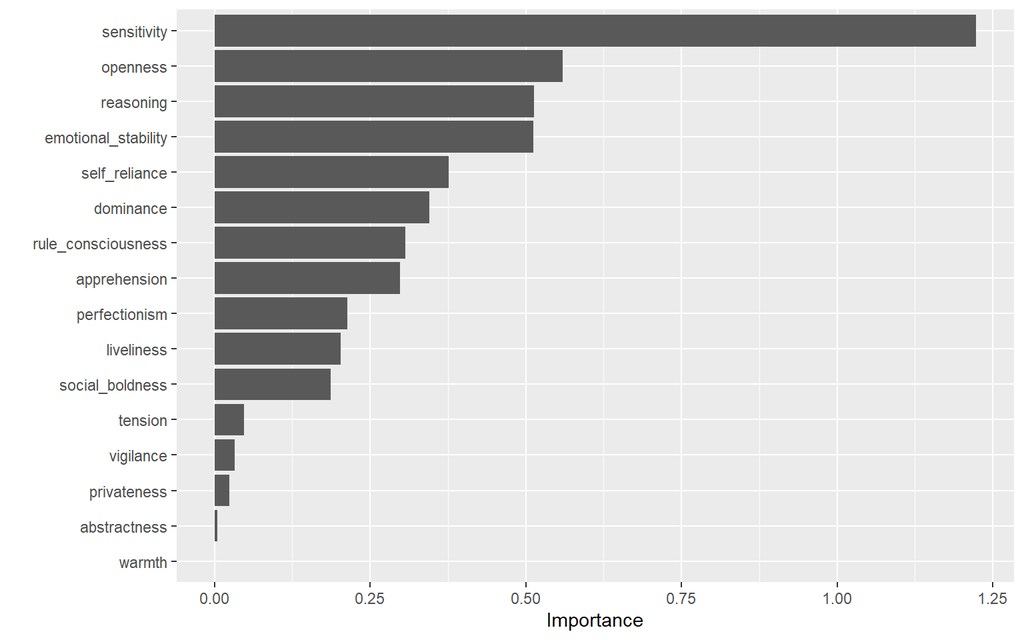

```r
EN_final_fitted <- elastic_tuned_final_t %>%
  tune::extract_workflow() %>%
  parsnip::fit(rsample::training(split_t))

# Ver la importancia de las características

EN_final_fitted %>%
  vip::vip(num_features = 16)
```

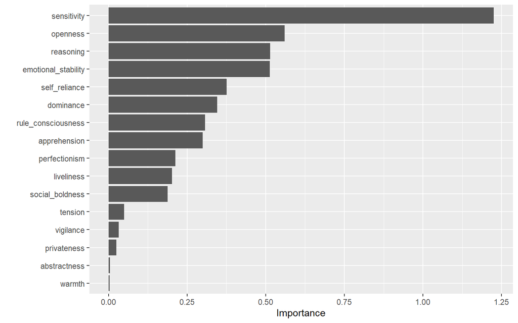

```r
EN_final_fitted_Base <- elastic_tuned_final %>%
  tune::extract_workflow() %>%
  parsnip::fit(rsample::training(split))

# Ver la importancia de las características

EN_final_fitted_Base %>%
  vip::vip(num_features = 16)
```

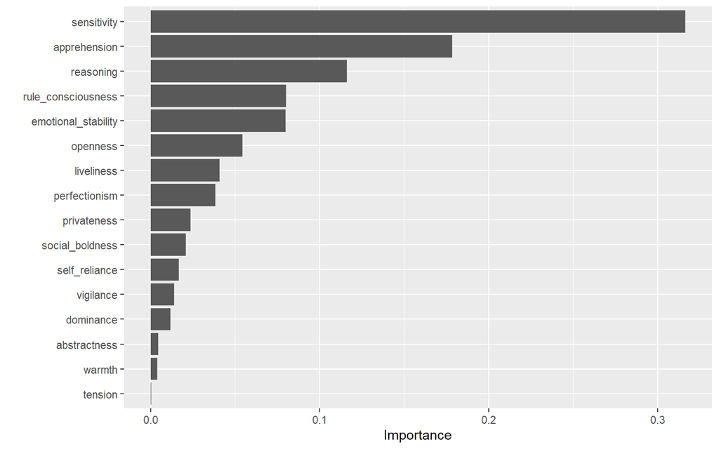

```r
lightGBM_final_fitted <- lightgbm_tuned_final_t %>%
  tune::extract_workflow() %>%
  parsnip::fit(rsample::training(split_t))

# Ver la importancia de las características
library(vip)
lightGBM_final_fitted %>%
  vip::vip(num_features = 16)
```

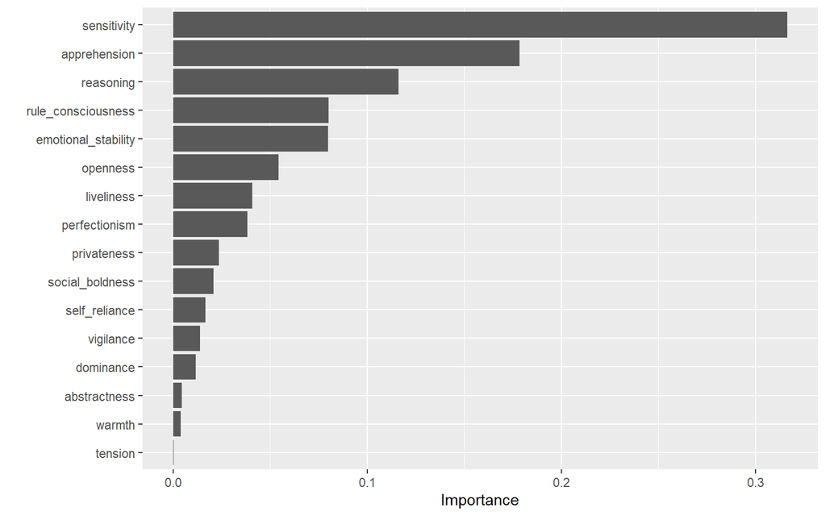

```r
lightGBM_final_fitted_Base <- lightgbm_tuned_final %>%
  tune::extract_workflow() %>%
  parsnip::fit(rsample::training(split))

# Ver la importancia de las características
library(vip)
lightGBM_final_fitted_Base %>%
  vip::vip(num_features = 16)
```

```r
# Creo un nuevo dataset para el argumento que pide la función (a set of new observations with columns that correspond to variables used in the model.

new_observations_complete <- rsample::testing(split) %>%
  head(50)

# Crear un preprocesador solo para imputar los valores faltantes en new_observations
preprocesador_imputacion_complete <- recipes::recipe(~ ., data = new_observations_complete) %>%
  recipes::step_impute_median(all_numeric_predictors())

# Preparar el preprocesador
preprocesador_imputacion_prep_complete <- recipes::prep(preprocesador_imputacion_complete, training = new_observations_complete)

# Aplicar el preprocesador a new_observations
new_observations_imputed_complete <- recipes::bake(preprocesador_imputacion_prep_complete, new_data = new_observations_complete)

# Convertir la variable gender a numérica  (las IA dijeron que el error podía ser porque gender es factor y la función necesita que todo sea numeric, pero me sigue dando el mismo error)
gender_numeric_complete <- ifelse(rsample::testing(split)$gender == "female", 0, 1)

# Crear el explainer
explainer_svm_complete <- DALEXtra::explain_tidymodels(
  svm_base_modelo_final$.workflow[[1]],
  data = rsample::testing(split) %>% dplyr::select(-gender),
  y = gender_numeric_complete,
  label = "SVM"
)
```

```
## Preparation of a new explainer is initiated
##   -> model label       :  SVM
##   -> data              :  83  rows  16  cols
##   -> data              :  tibble converted into a data.frame
##   -> target variable   :  83  values
##   -> predict function  :  yhat.workflow  will be used (  default  )
##   -> predicted values  :  No value for predict function target column. (  default  )
##   -> model_info        :  package tidymodels , ver. 1.2.0 , task classification (  default  )
##   -> predicted values  :  numerical, min =  0.0241175 , mean =  0.3899465 , max =  0.9267066
##   -> residual function :  difference between y and yhat (  default  )
##   -> residuals         :  numerical, min =  -0.880583 , mean =  0.01969203 , max =  0.7565566
##   A new explainer has been created!
```

```r
# Calcular valores SHAP agregados
shap_values_complete <- shap_aggregated(
  explainer = explainer_svm_complete,
  new_observations = new_observations_imputed_complete
)

# Verificar los valores SHAP
print(shap_values_complete)
```

```
## $aggregated
##               variable label  contribution position sign cumulative
## 18           intercept   SVM  3.899465e-01       19    X  0.3899465
## 1            reasoning   SVM -1.055517e-03       18   -1  0.3888910
## 2        perfectionism   SVM -2.555667e-03       17   -1  0.3863353
## 3      social_boldness   SVM  4.621066e-04       16    1  0.3867974
## 4           liveliness   SVM -4.684905e-03       15   -1  0.3821125
## 5              tension   SVM  3.523644e-04       14    1  0.3824649
## 6             openness   SVM -5.869598e-03       13   -1  0.3765953
## 7  emotional_stability   SVM -5.898991e-03       12   -1  0.3706963
## 8               warmth   SVM -6.784631e-04       11   -1  0.3700179
## 9            vigilance   SVM  9.155967e-04       10    1  0.3709335
## 10         privateness   SVM  1.698480e-06        9    1  0.3709351
## 11  rule_consciousness   SVM -1.610000e-02        8   -1  0.3548351
## 12       self_reliance   SVM -1.368949e-03        7   -1  0.3534662
## 13        apprehension   SVM -1.093538e-02        6   -1  0.3425308
## 14                <NA>  <NA>            NA        5 <NA>         NA
## 15           dominance   SVM  7.080100e-03        4    1         NA
## 16         sensitivity   SVM -7.246613e-02        3   -1         NA
## 17        abstractness   SVM -1.127116e-03        2   -1         NA
## 19          prediction   SVM  2.760177e-01        1    X  0.2760177
##          variable_name variable_value
## 18           intercept
## 1            reasoning
## 2        perfectionism
## 3      social_boldness
## 4           liveliness
## 5              tension
## 6             openness
## 7  emotional_stability
## 8               warmth
## 9            vigilance
## 10         privateness
## 11  rule_consciousness
## 12       self_reliance
## 13        apprehension
## 14                <NA>
## 15           dominance
## 16         sensitivity
## 17        abstractness
```

[output cut: 29 more lines]

```
## SVM: openness            -5.869598e-03  1.608175e-02 0.124192785
## SVM: perfectionism       -2.555667e-03  7.444514e-03 0.031966748
## SVM: prediction           2.760177e-01  3.688396e-01 0.880583011
## SVM: privateness          1.698480e-06  4.104153e-05 0.000179745
## SVM: reasoning           -1.055517e-03  5.248889e-02 0.156359618
## SVM: rule_consciousness  -1.610000e-02  1.281961e-02 0.099473873
## SVM: self_reliance       -1.368949e-03  1.413504e-02 0.089348317
## SVM: sensitivity         -7.246613e-02 -1.779155e-02 0.271412236
## SVM: social_boldness      4.621066e-04  1.439548e-02 0.061589734
## SVM: tension              3.523644e-04  5.334084e-03 0.025618769
## SVM: vigilance            9.155967e-04  7.992071e-03 0.030473890
## SVM: warmth              -6.784631e-04  1.485683e-03 0.006830623
##
## attr(,"class")
## [1] "shap_aggregated" "list"
```

> **Viendo las correlaciones, los factores que muestran una mayor deferencia de sexos son:**  
> - Sensitivity (.42)  
> - Apprehension (.33)  
> - Reasoning (.26)  
> - Rule consciousness (.20)  
> - Emotional stability (.20)  
> **Los que menos son:**  
> - Abstractness (0)  
> - Social boldness (0.01)  
> - Vigilance (0.02)  
> - Liviliness (0.06)  
> - Tension (0.07)  
> - Perfectionism (0.08)  
> - Privateness (0.09)  
> **Viendo el peso de los predictores en los modelos, los que más aportan son:**  
> - Sensitivity  
> - Apprehension  
> - Openess  
> - Reasoning  
> - Rule consciousness  
> - Emotional stability  
> **Los que menos:**  
> - Warmth  
> - Abstracteness  
> - Tension  
> **Los autores del paper encontraron un mayor efecto de las variables:**  
> - Sensitivity  
> - Apprehension  
> - Warmth  
> - Openess

## Probamos sin “warmth”

```r
Base_sinWarmth <- Train_data %>%
  select(1, 3:17)
```

## preprocesador_sW con transformaciones

```r
set.seed(975)
split_sW <- rsample::initial_split(
  Base_sinWarmth,
  strata = gender,
  prop = 0.8
)

split_sW
```

```
## <Training/Testing/Total>
## <329/83/412>
```

```r
set.seed(975)
cv_folds_sW <- rsample::vfold_cv(
  training(split_sW),
  strata = gender,
  v = 10,
  repeats = 10
)
```

```r
preprocesador_sW <- recipes::recipe(gender ~ ., data = rsample::training(split_sW)) %>%
  # Imputar valores ausentes
  recipes::step_naomit(all_outcomes()) %>%                               # Elimina missings en variable resultado
  recipes::step_impute_median(all_numeric_predictors()) %>%              # Al ser variables ordinales que van de 1 a 5 elegimos imputar con la mediana
  # Reducción de datos
  recipes::step_corr(all_numeric_predictors(), threshold = 0.9) %>%      # Elimina variables altamente correlacionadas
  recipes::step_nzv(all_predictors()) %>%                                # Elimina predictores con varianza muy baja o nula
  # Transformación y normalización de datos
  recipes::step_center(all_numeric_predictors()) %>%                    # Calcula X - Media
  recipes::step_scale(all_numeric_predictors())                         # Divide por SD. Juntas calculan z scores

preprocesador_sW
```

## Support Vector Machine Linear - con parámetros que vienen por defecto

```r
svm_Train_data_model_base_sW<- parsnip::svm_linear(
  mode = "classification",
  cost = NULL,      #default 1.0
  margin = NULL) %>%   #default 0.1
 set_engine("kernlab")
```

```r
# Creamos un workflow con el preprocesador_sW y el modelo
svm_Train_data_wflow_base_sW <- workflows::workflow() %>%
  workflows::add_recipe(preprocesador_sW) %>%
  workflows::add_model(svm_Train_data_model_base_sW)
```

```r
# Realizar la validación cruzada y guardar los resultados en un tibble

set.seed(975)
svm_Train_data_result_base_sW <- svm_Train_data_wflow_base_sW %>%
  tune::fit_resamples(
    cv_folds_sW,
    metrics = yardstick::metric_set(accuracy)) %>%
  tune::collect_metrics(summarize = FALSE) %>%
  dplyr::select(id, .metric, .estimate) %>%
  dplyr::mutate(model = "svm_Train_data_model_base_sW_cv")
```

```r
# Mostrar las métricas de la validación cruzada

svm_Train_data_result_base_sW %>%
  dplyr::group_by(.metric) %>%
  dplyr::summarise(mean = mean(.estimate), n_folds = n())
```

```
## # A tibble: 1 × 3
##   .metric   mean n_folds
##   <chr>    <dbl>   <int>
## 1 accuracy 0.746     100
```

```r
# Realizar el último ajuste del modelo con todos los datos de entrenamiento

svm_base_modelo_final_sW <- tune::last_fit(
  svm_Train_data_wflow_base_sW,
  split = split_sW,
  metrics = yardstick::metric_set(accuracy))
```

```r
# Métricas sobre los datos del test

svm_base_Train_data_result_test_sW <- svm_base_modelo_final_sW %>%
  tune::collect_metrics()%>%
  dplyr::select(.metric, .estimate) %>%
  dplyr::mutate(model = "SVM_Train_data_sW_test")

svm_base_Train_data_result_test_sW
```

```
## # A tibble: 1 × 3
##   .metric  .estimate model
##   <chr>        <dbl> <chr>
## 1 accuracy     0.795 SVM_Train_data_sW_test
```

## Support Vector Machine Linear - con ajuste de hiperparámetros

```r
# Definimos el modelo base SVM con los hiperparámetros a ajustar (cost y margin)
svm_tuned_model_sW <- parsnip::svm_linear(
  mode = "classification",
  cost = tune(),   # Hiperparámetro a ajustar
  margin = tune()  # Hiperparámetro a ajustar
) %>%
  set_engine("kernlab")
```

```r
# Workflow
svm_tuned_wflow_sW <- workflows::workflow() %>%
  workflows::add_recipe(preprocesador_sW) %>%
  workflows::add_model(svm_tuned_model_sW)
```

```r
# Usamos tune_bayes() para optimizar los parámetros

set.seed(975)

svm_tuned_results_sW <- tune::tune_bayes(
  svm_tuned_wflow_sW,
  resamples = cv_folds_sW,
  initial = 15,       # Configuraciones iniciales
  iter = 100,         # Iteraciones de búsqueda
  metrics = yardstick::metric_set(accuracy)
)
```

```r
# Mostramos los mejores hiperparámetros:

svm_tuned_results_sW %>%
  tune::show_best(metric = "accuracy", n = 10)
```

```
## # A tibble: 10 × 9
##     cost  margin .metric  .estimator  mean     n std_err .config           .iter
##    <dbl>   <dbl> <chr>    <chr>      <dbl> <int>   <dbl> <chr>             <int>
##  1 0.184 0.197   accuracy binary     0.752   100 0.00708 Iter10               10
##  2 0.185 0.107   accuracy binary     0.752   100 0.00711 Preprocessor1_Mo…     0
##  3 0.186 0.0518  accuracy binary     0.752   100 0.00707 Iter17               17
##  4 0.189 0.135   accuracy binary     0.751   100 0.00704 Iter8                 8
##  5 0.183 0.0180  accuracy binary     0.751   100 0.00713 Iter9                 9
##  6 0.182 0.199   accuracy binary     0.751   100 0.00713 Iter14               14
##  7 0.172 0.0548  accuracy binary     0.751   100 0.00704 Iter4                 4
##  8 0.306 0.0639  accuracy binary     0.750   100 0.00693 Iter7                 7
##  9 0.247 0.00146 accuracy binary     0.750   100 0.00707 Iter3                 3
## 10 0.213 0.118   accuracy binary     0.750   100 0.00711 Iter5                 5
```

```r
# Seleccionar los mejores hiperparámetros
svm_tuned_best_params_sW <- svm_tuned_results_sW %>%
  tune::select_best(metric = "accuracy")

# Guardar resultados de la validación cruzada
svm_tuned_results_cv_sW <- svm_tuned_results_sW %>%
  tune::collect_metrics(summarize = FALSE) %>%
  dplyr::filter(.config == svm_tuned_best_params_sW$.config) %>%
  dplyr::select(id, .metric, .estimate) %>%
  dplyr::mutate(model = "SVM_tuned_sW_cv")

# Resumen de métricas
svm_tuned_results_cv_sW %>%
  dplyr::group_by(.metric) %>%
  dplyr::summarise(mean = mean(.estimate), n_folds = n())
```

```
## # A tibble: 1 × 3
##   .metric   mean n_folds
##   <chr>    <dbl>   <int>
## 1 accuracy 0.752     100
```

```r
# Asignamos los mejores hiperparámetros al workflow y ajustamos el modelo final:

# Finalizar el workflow con los mejores hiperparámetros
svm_tuned_wflow_final_sW <- svm_tuned_wflow_sW %>%
  tune::finalize_workflow(svm_tuned_best_params_sW)

# Ajustar el modelo final en los datos de entrenamiento
svm_tuned_final_sW <- tune::last_fit(
  svm_tuned_wflow_final_sW,
  split = split_sW,
  metrics = yardstick::metric_set(accuracy)
)

# Métricas en los datos de prueba
svm_tuned_results_test_sW <- svm_tuned_final_sW %>%
  tune::collect_metrics() %>%
  dplyr::select(.metric, .estimate) %>%
  dplyr::mutate(model = "SVM_tuned_sW_test")

svm_tuned_results_test_sW
```

```
## # A tibble: 1 × 3
##   .metric  .estimate model
##   <chr>        <dbl> <chr>
## 1 accuracy     0.759 SVM_tuned_sW_test
```

# Compamos modelos

```r
metrica_a_graficar = "accuracy"

# Tabla de los resultados de la validación cruzada
dplyr::bind_rows(
  svm_Train_data_result_base,
  svm_tuned_results_cv,
  lightgbm_base_result_cv,
  lightgbm_tuned_results_cv,
  EN_base_result_cv,
  elastic_tuned_results_cv,
  svm_Train_data_result_base_t,
  svm_tuned_results_cv_t,
  lightgbm_base_result_cv_t,
  lightgbm_tuned_results_cv_t,
  EN_base_result_cv_t,
  elastic_tuned_results_cv_t,
  svm_Train_data_result_base_sW,
  svm_tuned_results_cv_sW,
) %>%
  dplyr::group_by(model, .metric) %>%
  dplyr::filter(.metric == metrica_a_graficar) %>%
  dplyr::summarise(mean = mean(.estimate), sd = sd(.estimate), n_folds = n())
```

```
## # A tibble: 13 × 5
## # Groups:   model [13]
##    model                           .metric   mean     sd n_folds
##    <chr>                           <chr>    <dbl>  <dbl>   <int>
##  1 EN_base                         accuracy 0.727 0.0630     200
##  2 Elastic_tuned                   accuracy 0.733 0.0740     100
##  3 LightGBM_tuned                  accuracy 0.752 0.0673     100
##  4 LightGBM_tuned_t_cv             accuracy 0.752 0.0673     100
##  5 SVM_Train_data_model_base       accuracy 0.744 0.0713     100
##  6 SVM_tuned                       accuracy 0.751 0.0706     100
##  7 SVM_tuned_sW_cv                 accuracy 0.752 0.0708     100
##  8 SVM_tuned_t_test                accuracy 0.751 0.0688     100
##  9 elastic_base_model_t_cv         accuracy 0.732 0.0743     100
## 10 lightgbm_base_model             accuracy 0.744 0.0657     100
## 11 lightgbm_base_model_t_cv        accuracy 0.744 0.0657     100
## 12 svm_Train_data_model_base_cv_t  accuracy 0.745 0.0711     100
## 13 svm_Train_data_model_base_sW_cv accuracy 0.746 0.0725     100
```

```r
# Tabla de los resultados del test
dplyr::bind_rows(
  svm_base_Train_data_result_test,
  svm_tuned_results_test,
  lightgbm_base_result_test,
  lightgbm_tuned_results_test,
  EN_base_result_test,
  elastic_tuned_results_test,
  svm_base_Train_data_result_test_t,
  svm_tuned_results_test_t,
  lightgbm_base_result_test_t,
  lightgbm_tuned_results_test_t,
  EN_base_result_test_t,
  elastic_tuned_results_test_t,
  svm_base_Train_data_result_test_sW,
  svm_tuned_results_test_sW,
) %>%
  dplyr::group_by(model, .metric) %>%
  dplyr::filter(.metric == metrica_a_graficar) %>%
  dplyr::summarise(mean = mean(.estimate), n_folds = n())
```

```
## # A tibble: 14 × 4
## # Groups:   model [14]
##    model                     .metric   mean n_folds
##    <chr>                     <chr>    <dbl>   <int>
##  1 EN_base_t                 accuracy 0.747       1
##  2 EN_base_test              accuracy 0.747       1
##  3 Elastic_tuned_t_test      accuracy 0.771       1
##  4 Elastic_tuned_test        accuracy 0.771       1
##  5 LightGBM_base_t_test      accuracy 0.723       1
##  6 LightGBM_base_test        accuracy 0.723       1
##  7 LightGBM_tuned_t_test     accuracy 0.735       1
##  8 LightGBM_tuned_test       accuracy 0.735       1
##  9 SVM_Train_data_base_train accuracy 0.783       1
## 10 SVM_Train_data_sW_test    accuracy 0.795       1
## 11 SVM_Train_data_t_test     accuracy 0.795       1
## 12 SVM_tuned_sW_test         accuracy 0.759       1
## 13 SVM_tuned_t_test          accuracy 0.771       1
## 14 SVM_tuned_test            accuracy 0.771       1
```

> El SVM sigue siendo el modelo con mejor accuracy. El accuracy es equivalente tanto tranformando la variable Warmth como sacándola.

## Probamos sin “warmth” y sin “Abstractness” que tiene una correlación de 0.

```r
Base_sWA <- Train_data %>%
  select(1, 3:10, 12:17)
```

## preprocesador_sW con transformaciones

```r
set.seed(975)
split_sWA <- rsample::initial_split(
  Base_sWA,
  strata = gender,
  prop = 0.8
)

split_sWA
```

```
## <Training/Testing/Total>
## <329/83/412>
```

```r
set.seed(975)
cv_folds_sWA <- rsample::vfold_cv(
  training(split_sWA),
  strata = gender,
  v = 10,
  repeats = 10
)
```

```r
preprocesador_sWA <- recipes::recipe(gender ~ ., data = rsample::training(split_sWA)) %>%
  # Imputar valores ausentes
  recipes::step_naomit(all_outcomes()) %>%                               # Elimina missings en variable resultado
  recipes::step_impute_median(all_numeric_predictors()) %>%              # Al ser variables ordinales que van de 1 a 5 elegimos imputar con la mediana
  # Reducción de datos
  recipes::step_corr(all_numeric_predictors(), threshold = 0.9) %>%      # Elimina variables altamente correlacionadas
  recipes::step_nzv(all_predictors()) %>%                                # Elimina predictores con varianza muy baja o nula
  # Transformación y normalización de datos
  recipes::step_center(all_numeric_predictors()) %>%                    # Calcula X - Media
  recipes::step_scale(all_numeric_predictors())                         # Divide por SD. Juntas calculan z scores

preprocesador_sWA
```

## Support Vector Machine Linear - con parámetros que vienen por defecto

```r
svm_Train_data_model_base_sWA <- parsnip::svm_linear(
  mode = "classification",
  cost = NULL,      #default 1.0
  margin = NULL) %>%   #default 0.1
 set_engine("kernlab")
```

```r
# Creamos un workflow con el preprocesador_sW y el modelo
svm_Train_data_wflow_base_sWA <- workflows::workflow() %>%
  workflows::add_recipe(preprocesador_sWA) %>%
  workflows::add_model(svm_Train_data_model_base_sWA)
```

```r
# Realizar la validación cruzada y guardar los resultados en un tibble

set.seed(975)
svm_Train_data_result_base_sWA <- svm_Train_data_wflow_base_sWA %>%
  tune::fit_resamples(
    cv_folds_sWA,
    metrics = yardstick::metric_set(accuracy)) %>%
  tune::collect_metrics(summarize = FALSE) %>%
  dplyr::select(id, .metric, .estimate) %>%
  dplyr::mutate(model = "svm_Train_data_model_base_sWA")
```

```r
# Mostrar las métricas de la validación cruzada

svm_Train_data_result_base_sWA %>%
  dplyr::group_by(.metric) %>%
  dplyr::summarise(mean = mean(.estimate), n_folds = n())
```

```
## # A tibble: 1 × 3
##   .metric   mean n_folds
##   <chr>    <dbl>   <int>
## 1 accuracy 0.741     100
```

```r
# Realizar el último ajuste del modelo con todos los datos de entrenamiento

svm_base_modelo_final_sWA <- tune::last_fit(
  svm_Train_data_wflow_base_sWA,
  split = split_sWA,
  metrics = yardstick::metric_set(accuracy))
```

```r
# Métricas sobre los datos del test

svm_base_Train_data_result_test_sWA <- svm_base_modelo_final_sWA %>%
  tune::collect_metrics()%>%
  dplyr::select(.metric, .estimate) %>%
  dplyr::mutate(model = "SVM_Train_data_sWA_test")

svm_base_Train_data_result_test_sWA
```

```
## # A tibble: 1 × 3
##   .metric  .estimate model
##   <chr>        <dbl> <chr>
## 1 accuracy     0.771 SVM_Train_data_sWA_test
```

## Support Vector Machine Linear - con ajuste de hiperparámetros

```r
# Definimos el modelo base SVM con los hiperparámetros a ajustar (cost y margin)
svm_tuned_model_sWA <- parsnip::svm_linear(
  mode = "classification",
  cost = tune(),   # Hiperparámetro a ajustar
  margin = tune()  # Hiperparámetro a ajustar
) %>%
  set_engine("kernlab")
```

```r
# Workflow
svm_tuned_wflow_sWA <- workflows::workflow() %>%
  workflows::add_recipe(preprocesador_sWA) %>%
  workflows::add_model(svm_tuned_model_sWA)
```

```r
# Usamos tune_bayes() para optimizar los parámetros

set.seed(975)

svm_tuned_results_sWA <- tune::tune_bayes(
  svm_tuned_wflow_sWA,
  resamples = cv_folds_sWA,
  initial = 15,       # Configuraciones iniciales
  iter = 100,         # Iteraciones de búsqueda
  metrics = yardstick::metric_set(accuracy)
)
```

```r
# Mostramos los mejores hiperparámetros:

svm_tuned_results_sWA %>%
  tune::show_best(metric = "accuracy", n = 10)
```

```
## # A tibble: 10 × 9
##     cost  margin .metric  .estimator  mean     n std_err .config .iter
##    <dbl>   <dbl> <chr>    <chr>      <dbl> <int>   <dbl> <chr>   <int>
##  1 0.166 0.0720  accuracy binary     0.748   100 0.00693 Iter9       9
##  2 0.165 0.00116 accuracy binary     0.748   100 0.00693 Iter12     12
##  3 0.165 0.124   accuracy binary     0.748   100 0.00693 Iter13     13
##  4 0.167 0.143   accuracy binary     0.748   100 0.00693 Iter16     16
##  5 0.164 0.118   accuracy binary     0.748   100 0.00693 Iter17     17
##  6 0.165 0.156   accuracy binary     0.748   100 0.00693 Iter18     18
##  7 0.166 0.131   accuracy binary     0.748   100 0.00693 Iter19     19
##  8 0.161 0.122   accuracy binary     0.748   100 0.00689 Iter10     10
##  9 0.122 0.157   accuracy binary     0.748   100 0.00688 Iter1       1
## 10 0.170 0.173   accuracy binary     0.748   100 0.00692 Iter11     11
```

```r
# Seleccionar los mejores hiperparámetros
svm_tuned_best_params_sWA <- svm_tuned_results_sWA %>%
  tune::select_best(metric = "accuracy")

# Guardar resultados de la validación cruzada
svm_tuned_results_cv_sWA <- svm_tuned_results_sWA %>%
  tune::collect_metrics(summarize = FALSE) %>%
  dplyr::filter(.config == svm_tuned_best_params_sWA$.config) %>%
  dplyr::select(id, .metric, .estimate) %>%
  dplyr::mutate(model = "SVM_tuned_sWA_cv")

# Resumen de métricas
svm_tuned_results_cv_sWA %>%
  dplyr::group_by(.metric) %>%
  dplyr::summarise(mean = mean(.estimate), n_folds = n())
```

```
## # A tibble: 1 × 3
##   .metric   mean n_folds
##   <chr>    <dbl>   <int>
## 1 accuracy 0.748     100
```

```r
# Asignamos los mejores hiperparámetros al workflow y ajustamos el modelo final:

# Finalizar el workflow con los mejores hiperparámetros
svm_tuned_wflow_final_sWA <- svm_tuned_wflow_sWA %>%
  tune::finalize_workflow(svm_tuned_best_params_sWA)

# Ajustar el modelo final en los datos de entrenamiento
svm_tuned_final_sWA <- tune::last_fit(
  svm_tuned_wflow_final_sWA,
  split = split_sWA,
  metrics = yardstick::metric_set(accuracy)
)

# Métricas en los datos de prueba
svm_tuned_results_test_sWA <- svm_tuned_final_sWA %>%
  tune::collect_metrics() %>%
  dplyr::select(.metric, .estimate) %>%
  dplyr::mutate(model = "SVM_tuned_sWA_test")

svm_tuned_results_test_sWA
```

```
## # A tibble: 1 × 3
##   .metric  .estimate model
##   <chr>        <dbl> <chr>
## 1 accuracy     0.759 SVM_tuned_sWA_test
```

# Compamos modelos

```r
metrica_a_graficar = "accuracy"

# Tabla de los resultados de la validación cruzada
dplyr::bind_rows(
  svm_Train_data_result_base,
  svm_tuned_results_cv,
  lightgbm_base_result_cv,
  lightgbm_tuned_results_cv,
  EN_base_result_cv,
  elastic_tuned_results_cv,
  svm_Train_data_result_base_t,
  svm_tuned_results_cv_t,
  lightgbm_base_result_cv_t,
  lightgbm_tuned_results_cv_t,
  EN_base_result_cv_t,
  elastic_tuned_results_cv_t,
  svm_Train_data_result_base_sW,
  svm_tuned_results_cv_sW,
  svm_Train_data_result_base_sWA,
  svm_tuned_results_cv_sWA,
) %>%
  dplyr::group_by(model, .metric) %>%
  dplyr::filter(.metric == metrica_a_graficar) %>%
  dplyr::summarise(mean = mean(.estimate), sd = sd(.estimate), n_folds = n())
```

```
## # A tibble: 15 × 5
## # Groups:   model [15]
##    model                           .metric   mean     sd n_folds
##    <chr>                           <chr>    <dbl>  <dbl>   <int>
##  1 EN_base                         accuracy 0.727 0.0630     200
##  2 Elastic_tuned                   accuracy 0.733 0.0740     100
##  3 LightGBM_tuned                  accuracy 0.752 0.0673     100
##  4 LightGBM_tuned_t_cv             accuracy 0.752 0.0673     100
##  5 SVM_Train_data_model_base       accuracy 0.744 0.0713     100
##  6 SVM_tuned                       accuracy 0.751 0.0706     100
##  7 SVM_tuned_sWA_cv                accuracy 0.748 0.0693     100
##  8 SVM_tuned_sW_cv                 accuracy 0.752 0.0708     100
##  9 SVM_tuned_t_test                accuracy 0.751 0.0688     100
## 10 elastic_base_model_t_cv         accuracy 0.732 0.0743     100
## 11 lightgbm_base_model             accuracy 0.744 0.0657     100
## 12 lightgbm_base_model_t_cv        accuracy 0.744 0.0657     100
## 13 svm_Train_data_model_base_cv_t  accuracy 0.745 0.0711     100
## 14 svm_Train_data_model_base_sWA   accuracy 0.741 0.0741     100
## 15 svm_Train_data_model_base_sW_cv accuracy 0.746 0.0725     100
```

```r
# Tabla de los resultados del test
dplyr::bind_rows(
  svm_base_Train_data_result_test,
  svm_tuned_results_test,
  lightgbm_base_result_test,
  lightgbm_tuned_results_test,
  EN_base_result_test,
  elastic_tuned_results_test,
  svm_base_Train_data_result_test_t,
  svm_tuned_results_test_t,
  lightgbm_base_result_test_t,
  lightgbm_tuned_results_test_t,
  EN_base_result_test_t,
  elastic_tuned_results_test_t,
  svm_base_Train_data_result_test_sW,
  svm_tuned_results_test_sW,
  svm_base_Train_data_result_test_sWA,
  svm_tuned_results_test_sWA,
) %>%
  dplyr::group_by(model, .metric) %>%
  dplyr::filter(.metric == metrica_a_graficar) %>%
  dplyr::summarise(mean = mean(.estimate), n_folds = n())
```

```
## # A tibble: 16 × 4
## # Groups:   model [16]
##    model                     .metric   mean n_folds
##    <chr>                     <chr>    <dbl>   <int>
##  1 EN_base_t                 accuracy 0.747       1
##  2 EN_base_test              accuracy 0.747       1
##  3 Elastic_tuned_t_test      accuracy 0.771       1
##  4 Elastic_tuned_test        accuracy 0.771       1
##  5 LightGBM_base_t_test      accuracy 0.723       1
##  6 LightGBM_base_test        accuracy 0.723       1
##  7 LightGBM_tuned_t_test     accuracy 0.735       1
##  8 LightGBM_tuned_test       accuracy 0.735       1
##  9 SVM_Train_data_base_train accuracy 0.783       1
## 10 SVM_Train_data_sWA_test   accuracy 0.771       1
## 11 SVM_Train_data_sW_test    accuracy 0.795       1
## 12 SVM_Train_data_t_test     accuracy 0.795       1
## 13 SVM_tuned_sWA_test        accuracy 0.759       1
## 14 SVM_tuned_sW_test         accuracy 0.759       1
## 15 SVM_tuned_t_test          accuracy 0.771       1
## 16 SVM_tuned_test            accuracy 0.771       1
```

> No mejoran las predicciones sacando “Abstactness”

# Probamos otra optimización para el SVM - Random Search

## Support Vector Machine Linear - con ajuste de hiperparámetros (Random Search)

```r
svm_RS_model_sW <- parsnip::svm_linear(
  mode = "classification",
  cost = tune(),   # Hiperparámetro a ajustar
) %>%
  set_engine("kernlab")

# Workflow
svm_RS_wflow_sW <- workflows::workflow() %>%
  workflows::add_recipe(preprocesador_sW) %>%
  workflows::add_model(svm_RS_model_sW)
```

```r
set.seed(975)

# Especificamos el espacio de hiperparámetros a explorar
param_grid <- grid_random(
  dials::cost(range = c(-3, 3)),   # Log-scale: 10^(-3) a 10^3
  size = 100                      # Número de configuraciones
)

# Ajuste usando random search
svm_RS_results_sW <- tune::tune_grid(
  svm_RS_wflow_sW,
  resamples = cv_folds_sW,
  grid = param_grid,
  metrics = yardstick::metric_set(accuracy)
)

# Mostramos los mejores hiperparámetros
svm_RS_results_sW %>%
  tune::show_best(metric = "accuracy", n = 10)
```

```
## # A tibble: 10 × 7
##     cost .metric  .estimator  mean     n std_err .config
##    <dbl> <chr>    <chr>      <dbl> <int>   <dbl> <chr>
##  1 0.184 accuracy binary     0.752   100 0.00711 Preprocessor1_Model080
##  2 0.187 accuracy binary     0.751   100 0.00709 Preprocessor1_Model003
##  3 0.188 accuracy binary     0.751   100 0.00704 Preprocessor1_Model068
##  4 0.180 accuracy binary     0.751   100 0.00711 Preprocessor1_Model056
##  5 0.235 accuracy binary     0.751   100 0.00704 Preprocessor1_Model048
##  6 0.198 accuracy binary     0.750   100 0.00709 Preprocessor1_Model023
##  7 0.168 accuracy binary     0.750   100 0.00705 Preprocessor1_Model044
##  8 0.213 accuracy binary     0.750   100 0.00711 Preprocessor1_Model037
##  9 0.161 accuracy binary     0.750   100 0.00699 Preprocessor1_Model041
## 10 0.227 accuracy binary     0.750   100 0.00704 Preprocessor1_Model091
```

```r
# Seleccionar los mejores hiperparámetros
svm_RS_best_params_sW <- svm_RS_results_sW %>%
  tune::select_best(metric = "accuracy")

# Guardar resultados de la validación cruzada
svm_RS_results_cv_sW <- svm_RS_results_sW %>%
  tune::collect_metrics(summarize = FALSE) %>%
  dplyr::filter(.config == svm_RS_best_params_sW$.config) %>%
  dplyr::select(id, .metric, .estimate) %>%
  dplyr::mutate(model = "SVM_RS_sW_cv")

# Resumen de métricas
svm_RS_results_cv_sW %>%
  dplyr::group_by(.metric) %>%
  dplyr::summarise(mean = mean(.estimate), n_folds = n())
```

```
## # A tibble: 1 × 3
##   .metric   mean n_folds
##   <chr>    <dbl>   <int>
## 1 accuracy 0.752     100
```

```r
# Finalizar el workflow con los mejores hiperparámetros
svm_RS_wflow_final_sW <- svm_RS_wflow_sW %>%
  tune::finalize_workflow(svm_RS_best_params_sW)

# Ajustar el modelo final en los datos de entrenamiento
svm_RS_final_sW <- tune::last_fit(
  svm_RS_wflow_final_sW,
  split = split_sW,
  metrics = yardstick::metric_set(accuracy)
)

# Métricas en los datos de prueba
svm_RS_results_test_sW <- svm_RS_final_sW %>%
  tune::collect_metrics() %>%
  dplyr::select(.metric, .estimate) %>%
  dplyr::mutate(model = "SVM_RS_sW_test")

svm_RS_results_test_sW
```

```
## # A tibble: 1 × 3
##   .metric  .estimate model
##   <chr>        <dbl> <chr>
## 1 accuracy     0.759 SVM_RS_sW_test
```

# Comparo modelos

```r
# Tabla de los resultados de la validación cruzada
dplyr::bind_rows(
  svm_Train_data_result_base,
  svm_tuned_results_cv,
  svm_Train_data_result_base_sW,
  svm_tuned_results_cv_sW,
  svm_RS_results_cv_sW,
) %>%
  dplyr::group_by(model, .metric) %>%
  dplyr::filter(.metric == metrica_a_graficar) %>%
  dplyr::summarise(mean = mean(.estimate), sd = sd(.estimate), n_folds = n())
```

```
## # A tibble: 5 × 5
## # Groups:   model [5]
##   model                           .metric   mean     sd n_folds
##   <chr>                           <chr>    <dbl>  <dbl>   <int>
## 1 SVM_RS_sW_cv                    accuracy 0.752 0.0711     100
## 2 SVM_Train_data_model_base       accuracy 0.744 0.0713     100
## 3 SVM_tuned                       accuracy 0.751 0.0706     100
## 4 SVM_tuned_sW_cv                 accuracy 0.752 0.0708     100
## 5 svm_Train_data_model_base_sW_cv accuracy 0.746 0.0725     100
```

```r
# Tabla de los resultados del test
dplyr::bind_rows(
  svm_base_Train_data_result_test,
  svm_tuned_results_test,
  svm_base_Train_data_result_test_sW,
  svm_tuned_results_test_sW,
  svm_RS_results_test_sW,
) %>%
  dplyr::group_by(model, .metric) %>%
  dplyr::filter(.metric == metrica_a_graficar) %>%
  dplyr::summarise(mean = mean(.estimate), n_folds = n())
```

```
## # A tibble: 5 × 4
## # Groups:   model [5]
##   model                     .metric   mean n_folds
##   <chr>                     <chr>    <dbl>   <int>
## 1 SVM_RS_sW_test            accuracy 0.759       1
## 2 SVM_Train_data_base_train accuracy 0.783       1
## 3 SVM_Train_data_sW_test    accuracy 0.795       1
## 4 SVM_tuned_sW_test         accuracy 0.759       1
## 5 SVM_tuned_test            accuracy 0.771       1
```

> **Al probar las predicciones con el test de entrenamiento el modelo con mejor accuracy es el SVM sin optimización de hiperparámetros y sin la variable Warmth.**

# Respuestas de la consigna 1

> **El modelo debe superar un umbral mínimo de capacidad predictora de 0.59 (moda).**

> **Al probar las predicciones con el test de entrenamiento el modelo con mejor accuracy es el SVM sin optimización de hiperparámetros y sin la variable Warmth.**

# Respuestas de la consigna 2

```r
# Creo un nuevo dataset para el argumento que pide la función (a set of new observations with columns that correspond to variables used in the model.

new_observations <- rsample::testing(split_sW) %>%
  head(50)

# Crear un preprocesador solo para imputar los valores faltantes en new_observations
preprocesador_imputacion <- recipes::recipe(~ ., data = new_observations) %>%
  recipes::step_impute_median(all_numeric_predictors())

# Preparar el preprocesador
preprocesador_imputacion_prep <- recipes::prep(preprocesador_imputacion, training = new_observations)

# Aplicar el preprocesador a new_observations
new_observations_imputed <- recipes::bake(preprocesador_imputacion_prep, new_data = new_observations)

# Convertir la variable gender a numérica  (las IA dijeron que el error podía ser porque gender es factor y la función necesita que todo sea numeric, pero me sigue dando el mismo error)
gender_numeric <- ifelse(rsample::testing(split_sW)$gender == "female", 0, 1)

# Crear el explainer
explainer_svm <- DALEXtra::explain_tidymodels(
  svm_base_modelo_final_sW$.workflow[[1]],
  data = rsample::testing(split_t) %>% dplyr::select(-gender),
  y = gender_numeric,
  label = "SVM"
)
```

```
## Preparation of a new explainer is initiated
##   -> model label       :  SVM
##   -> data              :  83  rows  16  cols
##   -> data              :  tibble converted into a data.frame
##   -> target variable   :  83  values
##   -> predict function  :  yhat.workflow  will be used (  default  )
##   -> predicted values  :  No value for predict function target column. (  default  )
##   -> model_info        :  package tidymodels , ver. 1.2.0 , task classification (  default  )
##   -> predicted values  :  numerical, min =  0.01666273 , mean =  0.3852716 , max =  0.937574
##   -> residual function :  difference between y and yhat (  default  )
##   -> residuals         :  numerical, min =  -0.9087651 , mean =  0.02436696 , max =  0.7757945
##   A new explainer has been created!
```

```r
# Calcular valores SHAP agregados
shap_values <- shap_aggregated(
  explainer = explainer_svm,
  new_observations = new_observations_imputed
)

# Verificar los valores SHAP
print(shap_values)
```

```
## $aggregated
##               variable label  contribution position sign cumulative
## 17           intercept   SVM  3.852716e-01       18    X  0.3852716
## 1          privateness   SVM  7.088358e-05       17    1  0.3853425
## 2             openness   SVM -6.647115e-03       16   -1  0.3786954
## 3          sensitivity   SVM -7.657736e-02       15   -1  0.3021180
## 4  emotional_stability   SVM -6.771803e-03       14   -1  0.2953462
## 5      social_boldness   SVM  3.740375e-04       13    1  0.2957202
## 6            dominance   SVM  6.925672e-03       12    1  0.3026459
## 7           liveliness   SVM -5.499272e-03       11   -1  0.2971466
## 8        perfectionism   SVM -2.313713e-03       10   -1  0.2948329
## 9            vigilance   SVM  4.539825e-04        9    1  0.2952869
## 10             tension   SVM  4.842671e-04        8    1  0.2957712
## 11           reasoning   SVM -1.319493e-03        7   -1  0.2944517
## 12  rule_consciousness   SVM -1.828238e-02        6   -1  0.2761693
## 13                <NA>  <NA>            NA        5 <NA>         NA
## 14        apprehension   SVM -9.607991e-03        4   -1         NA
## 15       self_reliance   SVM -1.304559e-03        3   -1         NA
## 16        abstractness   SVM -1.030957e-03        2   -1         NA
## 18          prediction   SVM  2.642258e-01        1    X  0.2642258
##          variable_name variable_value
## 17           intercept
## 1          privateness
## 2             openness
## 3          sensitivity
## 4  emotional_stability
## 5      social_boldness
## 6            dominance
## 7           liveliness
## 8        perfectionism
## 9            vigilance
## 10             tension
## 11           reasoning
## 12  rule_consciousness
## 13                <NA>
## 14        apprehension
## 15       self_reliance
## 16        abstractness
## 18
##
```

[output cut: 25 more lines]

```
## SVM: liveliness           0.017720716 0.16946928
## SVM: openness             0.016832236 0.13370460
## SVM: perfectionism        0.006926231 0.03184660
## SVM: prediction           0.360248287 0.90876509
## SVM: privateness          0.001349160 0.00596859
## SVM: reasoning            0.053750974 0.15891690
## SVM: rule_consciousness   0.014462094 0.11719805
## SVM: self_reliance        0.016112784 0.11397285
## SVM: sensitivity         -0.019976194 0.29129874
## SVM: social_boldness      0.017041386 0.07743896
## SVM: tension              0.008587056 0.04085003
## SVM: vigilance            0.003575217 0.01579007
##
## attr(,"class")
## [1] "shap_aggregated" "list"
```